# Model Deployment : Detecting and Analyzing Machine Learning Model Drift Using Open-Source Monitoring Tools

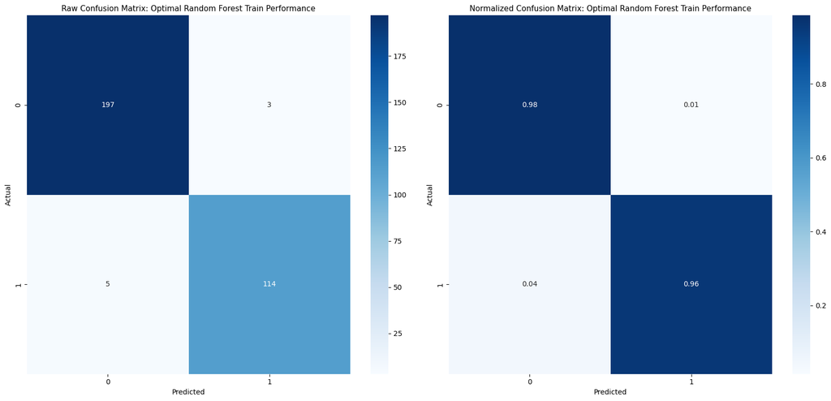

```python
##################################
# Formulating the raw and normalized
# confusion matrices
# from the train data
##################################
cm_raw = confusion_matrix(y_train_encoded, bagged_rf_optimal.predict(X_train))
cm_normalized = confusion_matrix(y_train_encoded, bagged_rf_optimal.predict(X_train), normalize='true')
fig, ax = plt.subplots(1, 2, figsize=(17, 8))
sns.heatmap(cm_raw, annot=True, fmt='d', cmap='Blues', ax=ax[0])
ax[0].set_title('Raw Confusion Matrix: Optimal Random Forest Train Performance', fontsize=11)
ax[0].set_xlabel('Predicted')
ax[0].set_ylabel('Actual')
sns.heatmap(cm_normalized, annot=True, fmt='.2f', cmap='Blues', ax=ax[1])
ax[1].set_title('Normalized Confusion Matrix: Optimal Random Forest Train Performance', fontsize=11)
ax[1].set_xlabel('Predicted')
ax[1].set_ylabel('Actual')
plt.tight_layout()
plt.show()
```

```python
##################################
# Summarizing the F1 score results
# and classification metrics
# on the validation data
# to assess overfitting optimism
##################################
print(f"F1 Score on Validation Data: {bagged_rf_optimal_f1_validation:.4f}")
print("\nClassification Report on Validation Data:\n", classification_report(y_validation_encoded, bagged_rf_optimal.predict(X_validation)))
```

```
F1 Score on Validation Data: 0.9067

Classification Report on Validation Data:
               precision    recall  f1-score   support

           0       0.92      0.99      0.95        67
           1       0.97      0.85      0.91        40

    accuracy                           0.93       107
   macro avg       0.94      0.92      0.93       107
weighted avg       0.94      0.93      0.93       107
```

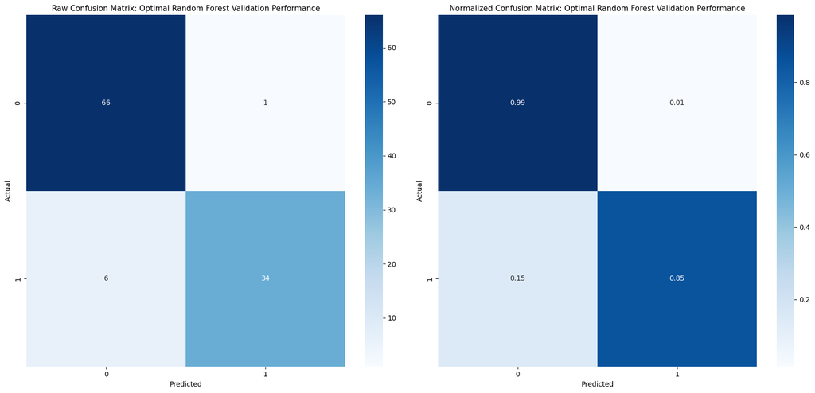

```python
##################################
# Formulating the raw and normalized
# confusion matrices
# from the validation data
##################################
cm_raw = confusion_matrix(y_validation_encoded, bagged_rf_optimal.predict(X_validation))
cm_normalized = confusion_matrix(y_validation_encoded, bagged_rf_optimal.predict(X_validation), normalize='true')
fig, ax = plt.subplots(1, 2, figsize=(17, 8))
sns.heatmap(cm_raw, annot=True, fmt='d', cmap='Blues', ax=ax[0])
ax[0].set_title('Raw Confusion Matrix: Optimal Random Forest Validation Performance', fontsize=11)
ax[0].set_xlabel('Predicted')
ax[0].set_ylabel('Actual')
sns.heatmap(cm_normalized, annot=True, fmt='.2f', cmap='Blues', ax=ax[1])
ax[1].set_title('Normalized Confusion Matrix: Optimal Random Forest Validation Performance', fontsize=11)
ax[1].set_xlabel('Predicted')
ax[1].set_ylabel('Actual')
plt.tight_layout()
plt.show()
```

```python
##################################
# Gathering the model evaluation metrics
# for the train data
##################################
bagged_rf_optimal_train = model_performance_evaluation(y_train_encoded, bagged_rf_optimal.predict(X_train))
bagged_rf_optimal_train['model'] = ['bagged_rf_optimal'] * 5
bagged_rf_optimal_train['set'] = ['train'] * 5
print('Optimal Random Forest Train Performance Metrics: ')
display(bagged_rf_optimal_train)
```

```
Optimal Random Forest Train Performance Metrics:
```

|  | metric_name | metric_value | model | set |
| --- | --- | --- | --- | --- |
| 0 | Accuracy | 0.974922 | bagged_rf_optimal | train |
| 1 | Precision | 0.974359 | bagged_rf_optimal | train |
| 2 | Recall | 0.957983 | bagged_rf_optimal | train |
| 3 | F1 | 0.966102 | bagged_rf_optimal | train |
| 4 | AUROC | 0.971492 | bagged_rf_optimal | train |

```python
##################################
# Gathering the model evaluation metrics
# for the validation data
##################################
bagged_rf_optimal_validation = model_performance_evaluation(y_validation_encoded, bagged_rf_optimal.predict(X_validation))
bagged_rf_optimal_validation['model'] = ['bagged_rf_optimal'] * 5
bagged_rf_optimal_validation['set'] = ['validation'] * 5
print('Optimal Random Forest Validation Performance Metrics: ')
display(bagged_rf_optimal_validation)
```

```
Optimal Random Forest Validation Performance Metrics:
```

|  | metric_name | metric_value | model | set |
| --- | --- | --- | --- | --- |
| 0 | Accuracy | 0.934579 | bagged_rf_optimal | validation |
| 1 | Precision | 0.971429 | bagged_rf_optimal | validation |
| 2 | Recall | 0.850000 | bagged_rf_optimal | validation |
| 3 | F1 | 0.906667 | bagged_rf_optimal | validation |
| 4 | AUROC | 0.917537 | bagged_rf_optimal | validation |

```python
##################################
# Saving the best individual model
# developed from the train data
##################################
joblib.dump(bagged_rf_optimal,
            os.path.join("..", MODELS_PATH, "bagged_model_random_forest_optimal.pkl"))
```

```
['..\\models\\bagged_model_random_forest_optimal.pkl']
```

### 1.7.2 AdaBoost

[AdaBoost (Adaptive Boosting)](https://scikit-learn.org/stable/modules/generated/sklearn.ensemble.AdaBoostClassifier.html) is a boosting technique that combines multiple weak learners — typically decision stumps (shallow trees) — to form a strong classifier. It works by iteratively training weak models, assigning higher weights to misclassified instances so that subsequent models focus on difficult cases. At each iteration, a new weak model is trained, and its predictions are combined using a weighted voting mechanism. This process continues until a stopping criterion is met, such as a predefined number of iterations or performance threshold. AdaBoost is advantageous because it improves accuracy without overfitting if regularized properly. It performs well with clean data and can transform weak classifiers into strong ones. However, it is sensitive to noisy data and outliers, as misclassified points receive higher importance, leading to potential overfitting. Additionally, training can be slow for large datasets, and performance depends on the choice of base learner, typically decision trees.

1. The [adaboost](https://scikit-learn.org/stable/modules/generated/sklearn.ensemble.AdaBoostClassifier.html) model from the **sklearn.ensemble** Python library API was implemented.
2. The model contains 3 hyperparameters for tuning:
   - estimator_max_depth = maximum depth of the tree made to vary between 1 and 2
   - learning_rate = weight applied to each classifier at each boosting iteration made to vary between 0.01 and 0.10
   - n_estimators = maximum number of estimators at which boosting is terminated made to vary between 50 and 100
3. No any hyperparameter was defined in the model address the minimal 1.7:1 class imbalance observed between the B and M diagnosis categories.
4. Hyperparameter tuning was conducted using the 5-cycle 5-fold cross-validation method with optimal model performance using the F1 score determined for:
   - estimator_max_depth = 2
   - learning_rate = 0.10
   - n_estimators = 100
5. The apparent model performance of the optimal model is summarized as follows:
   - **Accuracy** = 0.9937
   - **Precision** = 1.0000
   - **Recall** = 0.9831
   - **F1 Score** = 0.9915
   - **AUROC** = 0.9915
6. The independent validation model performance of the optimal model is summarized as follows:
   - **Accuracy** = 0.9439
   - **Precision** = 0.9722
   - **Recall** = 0.8750
   - **F1 Score** = 0.9210
   - **AUROC** = 0.9300
7. Sufficiently comparable apparent and independent validation model performance observed that might be indicative of the absence of excessive model overfitting.

```python
##################################
# Defining the scaling and PCA preprocessing parameters
##################################
scaling_pca_preprocessor = Pipeline([
    ('scaler', StandardScaler()),
    ('pca', PCA(n_components=10, random_state=987654321))
])
```

```python
##################################
# Defining the preprocessing and modeling pipeline parameters
##################################
boosted_ab_pipeline = Pipeline([
    ('scaling_pca_preprocessor', scaling_pca_preprocessor),
    ('boosted_ab_model', AdaBoostClassifier(estimator=DecisionTreeClassifier(random_state=987654321),
                                            random_state=987654321))
])
```

```python
##################################
# Defining hyperparameter grid
##################################
boosted_ab_hyperparameter_grid = {
    'boosted_ab_model__learning_rate': [0.01, 0.10],
    'boosted_ab_model__estimator__max_depth': [1, 2],
    'boosted_ab_model__n_estimators': [50, 100]
}
```

```python
##################################
# Defining the cross-validation strategy (5-cycle 5-fold CV)
##################################
cv_strategy = RepeatedStratifiedKFold(n_splits=5,
                                      n_repeats=5,
                                      random_state=987654321)
```

```python
##################################
# Performing Grid Search with cross-validation
##################################
boosted_ab_grid_search = GridSearchCV(
    estimator=boosted_ab_pipeline,
    param_grid=boosted_ab_hyperparameter_grid,
    scoring='f1',
    cv=cv_strategy,
    n_jobs=-1,
    verbose=1
)
```

```python
##################################
# Encoding the response variables
# for model training and validation
##################################
y_train_encoded = y_train.map({'B': 0, 'M': 1})
y_validation_encoded = y_validation.map({'B': 0, 'M': 1})
```

```python
##################################
# Fitting GridSearchCV
##################################
boosted_ab_grid_search.fit(X_train, y_train_encoded)
```

```
Fitting 25 folds for each of 8 candidates, totalling 200 fits
```

```
GridSearchCV(cv=RepeatedStratifiedKFold(n_repeats=5, n_splits=5, random_state=987654321),
             estimator=Pipeline(steps=[('scaling_pca_preprocessor',
                                        Pipeline(steps=[('scaler',
                                                         StandardScaler()),
                                                        ('pca',
                                                         PCA(n_components=10,
                                                             random_state=987654321))])),
                                       ('boosted_ab_model',
                                        AdaBoostClassifier(estimator=DecisionTreeClassifier(random_state=987654321),
                                                           random_state=987654321))]),
             n_jobs=-1,
             param_grid={'boosted_ab_model__estimator__max_depth': [1, 2],
                         'boosted_ab_model__learning_rate': [0.01, 0.1],
                         'boosted_ab_model__n_estimators': [50, 100]},
             scoring='f1', verbose=1)
```

```python
##################################
# Identifying the best model
##################################
boosted_ab_optimal = boosted_ab_grid_search.best_estimator_
```

```python
##################################
# Evaluating the F1 scores
# on the training, cross-validation, and validation data
##################################
boosted_ab_optimal_f1_cv = boosted_ab_grid_search.best_score_
boosted_ab_optimal_f1_train = f1_score(y_train_encoded, boosted_ab_optimal.predict(X_train))
boosted_ab_optimal_f1_validation = f1_score(y_validation_encoded, boosted_ab_optimal.predict(X_validation))
```

```python
##################################
# Identifying the optimal model
##################################
print('Best Boosted Model - AdaBoost: ')
print(f"Best AdaBoost Hyperparameters: {boosted_ab_grid_search.best_params_}")
```

```
Best Boosted Model - AdaBoost:
Best AdaBoost Hyperparameters: {'boosted_ab_model__estimator__max_depth': 2, 'boosted_ab_model__learning_rate': 0.1, 'boosted_ab_model__n_estimators': 100}
```

```python
##################################
# Summarizing the F1 score results
# and classification metrics
# on the training and cross-validated data
# to assess overfitting optimism
##################################
print(f"F1 Score on Cross-Validated Data: {boosted_ab_optimal_f1_cv:.4f}")
print(f"F1 Score on Training Data: {boosted_ab_optimal_f1_train:.4f}")
print("\nClassification Report on Train Data:\n", classification_report(y_train_encoded, boosted_ab_optimal.predict(X_train)))
```

```
F1 Score on Cross-Validated Data: 0.9280
F1 Score on Training Data: 0.9915

Classification Report on Train Data:
               precision    recall  f1-score   support

           0       0.99      1.00      1.00       200
           1       1.00      0.98      0.99       119

    accuracy                           0.99       319
   macro avg       1.00      0.99      0.99       319
weighted avg       0.99      0.99      0.99       319
```

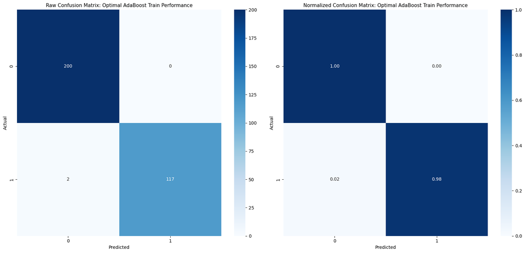

```python
##################################
# Formulating the raw and normalized
# confusion matrices
# from the train data
##################################
cm_raw = confusion_matrix(y_train_encoded, boosted_ab_optimal.predict(X_train))
cm_normalized = confusion_matrix(y_train_encoded, boosted_ab_optimal.predict(X_train), normalize='true')
fig, ax = plt.subplots(1, 2, figsize=(17, 8))
sns.heatmap(cm_raw, annot=True, fmt='d', cmap='Blues', ax=ax[0])
ax[0].set_title('Raw Confusion Matrix: Optimal AdaBoost Train Performance', fontsize=11)
ax[0].set_xlabel('Predicted')
ax[0].set_ylabel('Actual')
sns.heatmap(cm_normalized, annot=True, fmt='.2f', cmap='Blues', ax=ax[1])
ax[1].set_title('Normalized Confusion Matrix: Optimal AdaBoost Train Performance', fontsize=11)
ax[1].set_xlabel('Predicted')
ax[1].set_ylabel('Actual')
plt.tight_layout()
plt.show()
```

```python
##################################
# Summarizing the F1 score results
# and classification metrics
# on the validation data
# to assess overfitting optimism
##################################
print(f"F1 Score on Validation Data: {boosted_ab_optimal_f1_validation:.4f}")
print("\nClassification Report on Validation Data:\n", classification_report(y_validation_encoded, boosted_ab_optimal.predict(X_validation)))
```

```
F1 Score on Validation Data: 0.9211

Classification Report on Validation Data:
               precision    recall  f1-score   support

           0       0.93      0.99      0.96        67
           1       0.97      0.88      0.92        40

    accuracy                           0.94       107
   macro avg       0.95      0.93      0.94       107
weighted avg       0.95      0.94      0.94       107
```

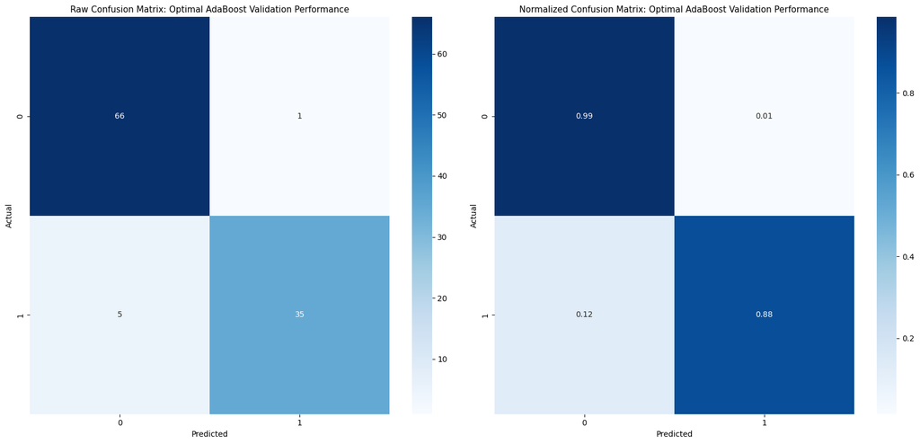

```python
##################################
# Formulating the raw and normalized
# confusion matrices
# from the validation data
##################################
cm_raw = confusion_matrix(y_validation_encoded, boosted_ab_optimal.predict(X_validation))
cm_normalized = confusion_matrix(y_validation_encoded, boosted_ab_optimal.predict(X_validation), normalize='true')
fig, ax = plt.subplots(1, 2, figsize=(17, 8))
sns.heatmap(cm_raw, annot=True, fmt='d', cmap='Blues', ax=ax[0])
ax[0].set_title('Raw Confusion Matrix: Optimal AdaBoost Validation Performance', fontsize=11)
ax[0].set_xlabel('Predicted')
ax[0].set_ylabel('Actual')
sns.heatmap(cm_normalized, annot=True, fmt='.2f', cmap='Blues', ax=ax[1])
ax[1].set_title('Normalized Confusion Matrix: Optimal AdaBoost Validation Performance', fontsize=11)
ax[1].set_xlabel('Predicted')
ax[1].set_ylabel('Actual')
plt.tight_layout()
plt.show()
```

```python
##################################
# Gathering the model evaluation metrics
# for the train data
##################################
boosted_ab_optimal_train = model_performance_evaluation(y_train_encoded, boosted_ab_optimal.predict(X_train))
boosted_ab_optimal_train['model'] = ['boosted_ab_optimal'] * 5
boosted_ab_optimal_train['set'] = ['train'] * 5
print('Optimal AdaBoost Train Performance Metrics: ')
display(boosted_ab_optimal_train)
```

```
Optimal AdaBoost Train Performance Metrics:
```

|  | metric_name | metric_value | model | set |
| --- | --- | --- | --- | --- |
| 0 | Accuracy | 0.993730 | boosted_ab_optimal | train |
| 1 | Precision | 1.000000 | boosted_ab_optimal | train |
| 2 | Recall | 0.983193 | boosted_ab_optimal | train |
| 3 | F1 | 0.991525 | boosted_ab_optimal | train |
| 4 | AUROC | 0.991597 | boosted_ab_optimal | train |

```python
##################################
# Gathering the model evaluation metrics
# for the validation data
##################################
boosted_ab_optimal_validation = model_performance_evaluation(y_validation_encoded, boosted_ab_optimal.predict(X_validation))
boosted_ab_optimal_validation['model'] = ['boosted_ab_optimal'] * 5
boosted_ab_optimal_validation['set'] = ['validation'] * 5
print('Optimal AdaBoost Validation Performance Metrics: ')
display(boosted_ab_optimal_validation)
```

```
Optimal AdaBoost Validation Performance Metrics:
```

|  | metric_name | metric_value | model | set |
| --- | --- | --- | --- | --- |
| 0 | Accuracy | 0.943925 | boosted_ab_optimal | validation |
| 1 | Precision | 0.972222 | boosted_ab_optimal | validation |
| 2 | Recall | 0.875000 | boosted_ab_optimal | validation |
| 3 | F1 | 0.921053 | boosted_ab_optimal | validation |
| 4 | AUROC | 0.930037 | boosted_ab_optimal | validation |

```python
##################################
# Saving the best individual model
# developed from the train data
##################################
joblib.dump(boosted_ab_optimal,
            os.path.join("..", MODELS_PATH, "boosted_model_adaboost_optimal.pkl"))
```

```
['..\\models\\boosted_model_adaboost_optimal.pkl']
```

### 1.7.3 Gradient Boosting

[Gradient Boosting](https://scikit-learn.org/stable/modules/generated/sklearn.ensemble.GradientBoostingClassifier.html) builds an ensemble of decision trees sequentially, where each new tree corrects the mistakes of the previous ones by optimizing a loss function. Unlike AdaBoost, which reweights misclassified instances, Gradient Boosting fits each new tree to the residual errors of the previous model, gradually improving predictions. This process continues until a stopping criterion, such as a set number of trees, is met. The key advantages of Gradient Boosting include its flexibility to model complex relationships and strong predictive performance, often outperforming bagging methods. It can handle both numeric and categorical data well. However, it is prone to overfitting if not carefully tuned, especially with deep trees and too many iterations. It is also computationally expensive due to sequential training, and hyperparameter tuning (e.g., learning rate, number of trees, tree depth) can be challenging and time-consuming.

1. The [gradient boosting](https://scikit-learn.org/stable/modules/generated/sklearn.ensemble.GradientBoostingClassifier.html) model from the **sklearn.ensemble** Python library API was implemented.
2. The model contains 4 hyperparameters for tuning:
   - learning_rate = shrinking proportion of the contribution from each tree made to vary between 0.01 and 0.10
   - max_depth = maximum depth of the tree made to vary between 3 and 6
   - min_samples_leaf = minimum number of samples required to be at a leaf node made to vary between 5 and 10
   - n_estimators = number of boosting stages to perform made to vary between 50 and 100
3. No any hyperparameter was defined in the model to address the minimal 1.7:1 class imbalance observed between the B and M diagnosis categories.
4. Hyperparameter tuning was conducted using the 5-cycle 5-fold cross-validation method with optimal model performance using the F1 score determined for:
   - learning_rate = 0.10
   - max_depth = 3
   - min_samples_leaf = 10
   - n_estimators = 100
5. The apparent model performance of the optimal model is summarized as follows:
   - **Accuracy** = 1.0000
   - **Precision** = 1.0000
   - **Recall** = 1.0000
   - **F1 Score** = 1.0000
   - **AUROC** = 1.0000
6. The independent validation model performance of the optimal model is summarized as follows:
   - **Accuracy** = 0.9345
   - **Precision** = 0.9714
   - **Recall** = 0.8500
   - **F1 Score** = 0.9066
   - **AUROC** = 0.9175
7. Sufficiently comparable apparent and independent validation model performance observed that might be indicative of the absence of excessive model overfitting.

```python
##################################
# Defining the scaling and PCA preprocessing parameters
##################################
scaling_pca_preprocessor = Pipeline([
    ('scaler', StandardScaler()),
    ('pca', PCA(n_components=10, random_state=987654321))
])
```

```python
##################################
# Defining the preprocessing and modeling pipeline parameters
##################################
boosted_gb_pipeline = Pipeline([
    ('scaling_pca_preprocessor', scaling_pca_preprocessor),
    ('boosted_gb_model', GradientBoostingClassifier(n_iter_no_change=10,
                                                    validation_fraction=0.1,
                                                    tol=1e-4,
                                                    random_state=987654321))
])
```

```python
##################################
# Defining hyperparameter grid
##################################
boosted_gb_hyperparameter_grid = {
    'boosted_gb_model__learning_rate': [0.01, 0.10],
    'boosted_gb_model__max_depth': [3, 6],
    'boosted_gb_model__min_samples_leaf': [5, 10],
    'boosted_gb_model__n_estimators': [50, 100]
}
```

```python
##################################
# Defining the cross-validation strategy (5-cycle 5-fold CV)
##################################
cv_strategy = RepeatedStratifiedKFold(n_splits=5,
                                      n_repeats=5,
                                      random_state=987654321)
```

```python
##################################
# Performing Grid Search with cross-validation
##################################
boosted_gb_grid_search = GridSearchCV(
    estimator=boosted_gb_pipeline,
    param_grid=boosted_gb_hyperparameter_grid,
    scoring='f1',
    cv=cv_strategy,
    n_jobs=-1,
    verbose=1
)
```

```python
##################################
# Encoding the response variables
# for model training and validation
##################################
y_train_encoded = y_train.map({'B': 0, 'M': 1})
y_validation_encoded = y_validation.map({'B': 0, 'M': 1})
```

```python
##################################
# Fitting GridSearchCV
##################################
boosted_gb_grid_search.fit(X_train, y_train_encoded)
```

```
Fitting 25 folds for each of 16 candidates, totalling 400 fits
```

```
GridSearchCV(cv=RepeatedStratifiedKFold(n_repeats=5, n_splits=5, random_state=987654321),
             estimator=Pipeline(steps=[('scaling_pca_preprocessor',
                                        Pipeline(steps=[('scaler',
                                                         StandardScaler()),
                                                        ('pca',
                                                         PCA(n_components=10,
                                                             random_state=987654321))])),
                                       ('boosted_gb_model',
                                        GradientBoostingClassifier(n_iter_no_change=10,
                                                                   random_state=987654321))]),
             n_jobs=-1,
             param_grid={'boosted_gb_model__learning_rate': [0.01, 0.1],
                         'boosted_gb_model__max_depth': [3, 6],
                         'boosted_gb_model__min_samples_leaf': [5, 10],
                         'boosted_gb_model__n_estimators': [50, 100]},
             scoring='f1', verbose=1)
```

```python
##################################
# Identifying the best model
##################################
boosted_gb_optimal = boosted_gb_grid_search.best_estimator_
```

```python
##################################
# Evaluating the F1 scores
# on the training, cross-validation, and validation data
##################################
boosted_gb_optimal_f1_cv = boosted_gb_grid_search.best_score_
boosted_gb_optimal_f1_train = f1_score(y_train_encoded, boosted_gb_optimal.predict(X_train))
boosted_gb_optimal_f1_validation = f1_score(y_validation_encoded, boosted_gb_optimal.predict(X_validation))
```

```python
##################################
# Identifying the optimal model
##################################
print('Best Boosted Model - Gradient Boosting: ')
print(f"Best Gradient Boosting Hyperparameters: {boosted_gb_grid_search.best_params_}")
```

```
Best Boosted Model - Gradient Boosting:
Best Gradient Boosting Hyperparameters: {'boosted_gb_model__learning_rate': 0.1, 'boosted_gb_model__max_depth': 3, 'boosted_gb_model__min_samples_leaf': 10, 'boosted_gb_model__n_estimators': 100}
```

```python
##################################
# Summarizing the F1 score results
# and classification metrics
# on the training and cross-validated data
# to assess overfitting optimism
##################################
print(f"F1 Score on Cross-Validated Data: {boosted_gb_optimal_f1_cv:.4f}")
print(f"F1 Score on Training Data: {boosted_gb_optimal_f1_train:.4f}")
print("\nClassification Report on Train Data:\n", classification_report(y_train_encoded, boosted_gb_optimal.predict(X_train)))
```

```
F1 Score on Cross-Validated Data: 0.9330
F1 Score on Training Data: 1.0000

Classification Report on Train Data:
               precision    recall  f1-score   support

           0       1.00      1.00      1.00       200
           1       1.00      1.00      1.00       119

    accuracy                           1.00       319
   macro avg       1.00      1.00      1.00       319
weighted avg       1.00      1.00      1.00       319
```

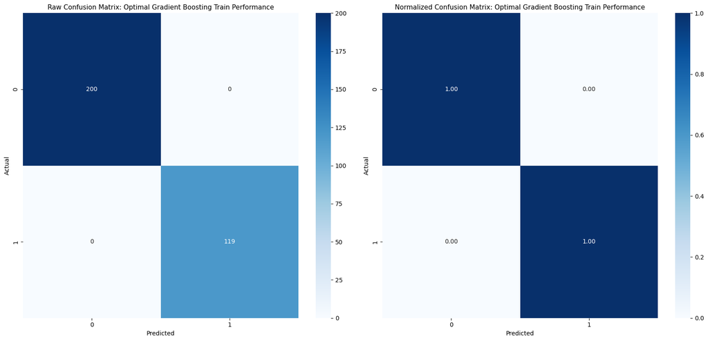

```python
##################################
# Formulating the raw and normalized
# confusion matrices
# from the train data
##################################
cm_raw = confusion_matrix(y_train_encoded, boosted_gb_optimal.predict(X_train))
cm_normalized = confusion_matrix(y_train_encoded, boosted_gb_optimal.predict(X_train), normalize='true')
fig, ax = plt.subplots(1, 2, figsize=(17, 8))
sns.heatmap(cm_raw, annot=True, fmt='d', cmap='Blues', ax=ax[0])
ax[0].set_title('Raw Confusion Matrix: Optimal Gradient Boosting Train Performance', fontsize=11)
ax[0].set_xlabel('Predicted')
ax[0].set_ylabel('Actual')
sns.heatmap(cm_normalized, annot=True, fmt='.2f', cmap='Blues', ax=ax[1])
ax[1].set_title('Normalized Confusion Matrix: Optimal Gradient Boosting Train Performance', fontsize=11)
ax[1].set_xlabel('Predicted')
ax[1].set_ylabel('Actual')
plt.tight_layout()
plt.show()
```

```python
##################################
# Summarizing the F1 score results
# and classification metrics
# on the validation data
# to assess overfitting optimism
##################################
print(f"F1 Score on Validation Data: {boosted_gb_optimal_f1_validation:.4f}")
print("\nClassification Report on Validation Data:\n", classification_report(y_validation_encoded, boosted_gb_optimal.predict(X_validation)))
```

```
F1 Score on Validation Data: 0.9067

Classification Report on Validation Data:
               precision    recall  f1-score   support

           0       0.92      0.99      0.95        67
           1       0.97      0.85      0.91        40

    accuracy                           0.93       107
   macro avg       0.94      0.92      0.93       107
weighted avg       0.94      0.93      0.93       107
```

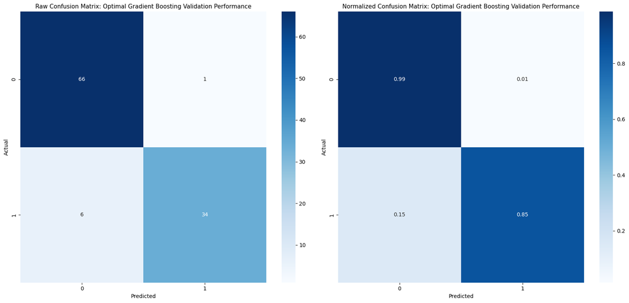

```python
##################################
# Formulating the raw and normalized
# confusion matrices
# from the validation data
##################################
cm_raw = confusion_matrix(y_validation_encoded, boosted_gb_optimal.predict(X_validation))
cm_normalized = confusion_matrix(y_validation_encoded, boosted_gb_optimal.predict(X_validation), normalize='true')
fig, ax = plt.subplots(1, 2, figsize=(17, 8))
sns.heatmap(cm_raw, annot=True, fmt='d', cmap='Blues', ax=ax[0])
ax[0].set_title('Raw Confusion Matrix: Optimal Gradient Boosting Validation Performance', fontsize=11)
ax[0].set_xlabel('Predicted')
ax[0].set_ylabel('Actual')
sns.heatmap(cm_normalized, annot=True, fmt='.2f', cmap='Blues', ax=ax[1])
ax[1].set_title('Normalized Confusion Matrix: Optimal Gradient Boosting Validation Performance', fontsize=11)
ax[1].set_xlabel('Predicted')
ax[1].set_ylabel('Actual')
plt.tight_layout()
plt.show()
```

```python
##################################
# Gathering the model evaluation metrics
# for the train data
##################################
boosted_gb_optimal_train = model_performance_evaluation(y_train_encoded, boosted_gb_optimal.predict(X_train))
boosted_gb_optimal_train['model'] = ['boosted_gb_optimal'] * 5
boosted_gb_optimal_train['set'] = ['train'] * 5
print('Optimal Gradient Boosting Train Performance Metrics: ')
display(boosted_gb_optimal_train)
```

```
Optimal Gradient Boosting Train Performance Metrics:
```

|  | metric_name | metric_value | model | set |
| --- | --- | --- | --- | --- |
| 0 | Accuracy | 1.0 | boosted_gb_optimal | train |
| 1 | Precision | 1.0 | boosted_gb_optimal | train |
| 2 | Recall | 1.0 | boosted_gb_optimal | train |
| 3 | F1 | 1.0 | boosted_gb_optimal | train |
| 4 | AUROC | 1.0 | boosted_gb_optimal | train |

```python
##################################
# Gathering the model evaluation metrics
# for the validation data
##################################
boosted_gb_optimal_validation = model_performance_evaluation(y_validation_encoded, boosted_gb_optimal.predict(X_validation))
boosted_gb_optimal_validation['model'] = ['boosted_gb_optimal'] * 5
boosted_gb_optimal_validation['set'] = ['validation'] * 5
print('Optimal Gradient Boosting Validation Performance Metrics: ')
display(boosted_gb_optimal_validation)
```

```
Optimal Gradient Boosting Validation Performance Metrics:
```

|  | metric_name | metric_value | model | set |
| --- | --- | --- | --- | --- |
| 0 | Accuracy | 0.934579 | boosted_gb_optimal | validation |
| 1 | Precision | 0.971429 | boosted_gb_optimal | validation |
| 2 | Recall | 0.850000 | boosted_gb_optimal | validation |
| 3 | F1 | 0.906667 | boosted_gb_optimal | validation |
| 4 | AUROC | 0.917537 | boosted_gb_optimal | validation |

```python
##################################
# Saving the best individual model
# developed from the train data
##################################
joblib.dump(boosted_gb_optimal,
            os.path.join("..", MODELS_PATH, "boosted_model_gradient_boosting_optimal.pkl"))
```

```
['..\\models\\boosted_model_gradient_boosting_optimal.pkl']
```

### 1.7.4 XGBoost

[XGBoost (Extreme Gradient Boosting)](https://xgboost.readthedocs.io/en/stable/python/index.html) is an optimized version of Gradient Boosting that introduces additional regularization and computational efficiencies. It builds decision trees sequentially, with each new tree correcting the residual errors of the previous ones, but it incorporates advanced techniques such as shrinkage (learning rate), column subsampling, and L1/L2 regularization to prevent overfitting. Additionally, XGBoost employs parallelization, reducing training time significantly compared to standard Gradient Boosting. It is widely used in machine learning competitions due to its superior accuracy and efficiency. The key advantages include its ability to handle missing data, built-in regularization for better generalization, and fast training through parallelization. However, XGBoost requires careful hyperparameter tuning to achieve optimal performance, and the model can become overly complex, making interpretation difficult. It is also memory-intensive, especially for large datasets, and can be challenging to deploy efficiently in real-time applications.

1. The [xgboost](https://xgboost.readthedocs.io/en/stable/python/index.html) model from the **xgboost** Python library API was implemented.
2. The model contains 4 hyperparameters for tuning:
   - learning_rate = step size at which weights are updated during training made to vary between 0.01 and 0.10
   - max_depth = maximum depth of the tree made to vary between 3 and 6
   - gamma = minimum loss reduction required to make a further split in a tree made to vary between 0.10 and 0.20
   - n_estimators = number of boosting stages to perform made to vary between 50 and 100
3. A special hyperparameter (scale_pos_weight = 1.7) was fixed to address the minimal 1.7:1 class imbalance observed between the B and M diagnosis categories.
4. Hyperparameter tuning was conducted using the 5-cycle 5-fold cross-validation method with optimal model performance using the F1 score determined for:
   - learning_rate = 0.10
   - max_depth = 6
   - gamma 0.20
   - n_estimators = 100
5. The apparent model performance of the optimal model is summarized as follows:
   - **Accuracy** = 1.0000
   - **Precision** = 1.0000
   - **Recall** = 1.0000
   - **F1 Score** = 1.0000
   - **AUROC** = 1.0000
6. The independent validation model performance of the optimal model is summarized as follows:
   - **Accuracy** = 0.9439
   - **Precision** = 0.9722
   - **Recall** = 0.8750
   - **F1 Score** = 0.9210
   - **AUROC** = 0.9300
7. Sufficiently comparable apparent and independent validation model performance observed that might be indicative of the absence of excessive model overfitting.

```python
##################################
# Defining the scaling and PCA preprocessing parameters
##################################
scaling_pca_preprocessor = Pipeline([
    ('scaler', StandardScaler()),
    ('pca', PCA(n_components=10, random_state=987654321))
])
```

```python
##################################
# Defining the preprocessing and modeling pipeline parameters
##################################
boosted_xgb_pipeline = Pipeline([
    ('scaling_pca_preprocessor', scaling_pca_preprocessor),
    ('boosted_xgb_model', XGBClassifier(scale_pos_weight=1.7,
                                        random_state=987654321,
                                        subsample=0.7,
                                        colsample_bytree=0.7,
                                        eval_metric='logloss'))
])
```

```python
##################################
# Defining hyperparameter grid
##################################
boosted_xgb_hyperparameter_grid = {
    'boosted_xgb_model__learning_rate': [0.01, 0.10],
    'boosted_xgb_model__max_depth': [3, 6],
    'boosted_xgb_model__gamma': [0.1, 0.2],
    'boosted_xgb_model__n_estimators': [50, 100]
}
```

```python
##################################
# Defining the cross-validation strategy (5-cycle 5-fold CV)
##################################
cv_strategy = RepeatedStratifiedKFold(n_splits=5,
                                      n_repeats=5,
                                      random_state=987654321)
```

```python
##################################
# Performing Grid Search with cross-validation
##################################
boosted_xgb_grid_search = GridSearchCV(
    estimator=boosted_xgb_pipeline,
    param_grid=boosted_xgb_hyperparameter_grid,
    scoring='f1',
    cv=cv_strategy,
    n_jobs=-1,
    verbose=1
)
```

```python
##################################
# Encoding the response variables
# for model training and validation
##################################
y_train_encoded = y_train.map({'B': 0, 'M': 1})
y_validation_encoded = y_validation.map({'B': 0, 'M': 1})
```

```python
##################################
# Fitting GridSearchCV
##################################
boosted_xgb_grid_search.fit(X_train, y_train_encoded)
```

```
Fitting 25 folds for each of 16 candidates, totalling 400 fits
```

```
GridSearchCV(cv=RepeatedStratifiedKFold(n_repeats=5, n_splits=5, random_state=987654321),
             estimator=Pipeline(steps=[('scaling_pca_preprocessor',
                                        Pipeline(steps=[('scaler',
                                                         StandardScaler()),
                                                        ('pca',
                                                         PCA(n_components=10,
                                                             random_state=987654321))])),
                                       ('boosted_xgb_model',
                                        XGBClassifier(base_score=None,
                                                      booster=None,
                                                      callbacks=None,
                                                      colsample_bylevel=None,
                                                      colsampl...
                                                      missing=nan,
                                                      monotone_constraints=None,
                                                      multi_strategy=None,
                                                      n_estimators=None,
                                                      n_jobs=None,
                                                      num_parallel_tree=None,
                                                      random_state=987654321, ...))]),
             n_jobs=-1,
             param_grid={'boosted_xgb_model__gamma': [0.1, 0.2],
                         'boosted_xgb_model__learning_rate': [0.01, 0.1],
                         'boosted_xgb_model__max_depth': [3, 6],
                         'boosted_xgb_model__n_estimators': [50, 100]},
             scoring='f1', verbose=1)
```

```python
##################################
# Identifying the best model
##################################
boosted_xgb_optimal = boosted_xgb_grid_search.best_estimator_
```

```python
##################################
# Evaluating the F1 scores
# on the training, cross-validation, and validation data
##################################
boosted_xgb_optimal_f1_cv = boosted_xgb_grid_search.best_score_
boosted_xgb_optimal_f1_train = f1_score(y_train_encoded, boosted_xgb_optimal.predict(X_train))
boosted_xgb_optimal_f1_validation = f1_score(y_validation_encoded, boosted_xgb_optimal.predict(X_validation))
```

```python
##################################
# Identifying the optimal model
##################################
print('Best Boosted Model - XGBoost: ')
print(f"Best XGBoost Hyperparameters: {boosted_xgb_grid_search.best_params_}")
```

```
Best Boosted Model - XGBoost:
Best XGBoost Hyperparameters: {'boosted_xgb_model__gamma': 0.2, 'boosted_xgb_model__learning_rate': 0.1, 'boosted_xgb_model__max_depth': 6, 'boosted_xgb_model__n_estimators': 100}
```

```python
##################################
# Summarizing the F1 score results
# and classification metrics
# on the training and cross-validated data
# to assess overfitting optimism
##################################
print(f"F1 Score on Cross-Validated Data: {boosted_xgb_optimal_f1_cv:.4f}")
print(f"F1 Score on Training Data: {boosted_xgb_optimal_f1_train:.4f}")
print("\nClassification Report on Train Data:\n", classification_report(y_train_encoded, boosted_xgb_optimal.predict(X_train)))
```

```
F1 Score on Cross-Validated Data: 0.9461
F1 Score on Training Data: 1.0000

Classification Report on Train Data:
               precision    recall  f1-score   support

           0       1.00      1.00      1.00       200
           1       1.00      1.00      1.00       119

    accuracy                           1.00       319
   macro avg       1.00      1.00      1.00       319
weighted avg       1.00      1.00      1.00       319
```

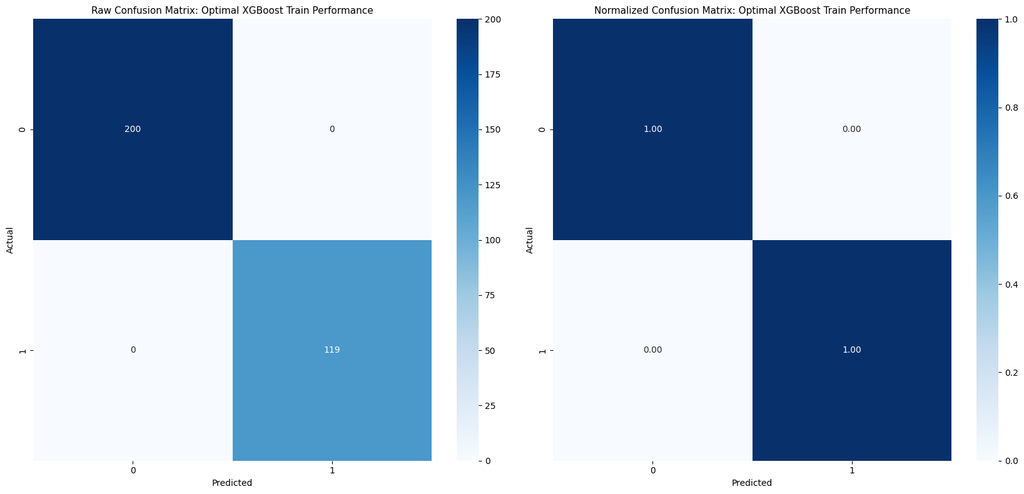

```python
##################################
# Formulating the raw and normalized
# confusion matrices
# from the train data
##################################
cm_raw = confusion_matrix(y_train_encoded, boosted_xgb_optimal.predict(X_train))
cm_normalized = confusion_matrix(y_train_encoded, boosted_xgb_optimal.predict(X_train), normalize='true')
fig, ax = plt.subplots(1, 2, figsize=(17, 8))
sns.heatmap(cm_raw, annot=True, fmt='d', cmap='Blues', ax=ax[0])
ax[0].set_title('Raw Confusion Matrix: Optimal XGBoost Train Performance', fontsize=11)
ax[0].set_xlabel('Predicted')
ax[0].set_ylabel('Actual')
sns.heatmap(cm_normalized, annot=True, fmt='.2f', cmap='Blues', ax=ax[1])
ax[1].set_title('Normalized Confusion Matrix: Optimal XGBoost Train Performance', fontsize=11)
ax[1].set_xlabel('Predicted')
ax[1].set_ylabel('Actual')
plt.tight_layout()
plt.show()
```

```python
##################################
# Summarizing the F1 score results
# and classification metrics
# on the validation data
# to assess overfitting optimism
##################################
print(f"F1 Score on Validation Data: {boosted_xgb_optimal_f1_validation:.4f}")
print("\nClassification Report on Validation Data:\n", classification_report(y_validation_encoded, boosted_xgb_optimal.predict(X_validation)))
```

```
F1 Score on Validation Data: 0.9211

Classification Report on Validation Data:
               precision    recall  f1-score   support

           0       0.93      0.99      0.96        67
           1       0.97      0.88      0.92        40

    accuracy                           0.94       107
   macro avg       0.95      0.93      0.94       107
weighted avg       0.95      0.94      0.94       107
```

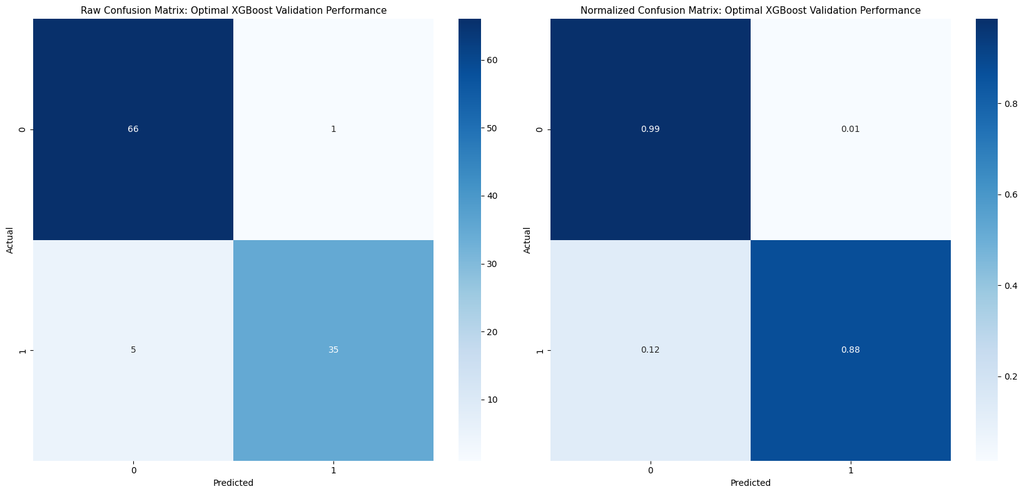

```python
##################################
# Formulating the raw and normalized
# confusion matrices
# from the validation data
##################################
cm_raw = confusion_matrix(y_validation_encoded, boosted_xgb_optimal.predict(X_validation))
cm_normalized = confusion_matrix(y_validation_encoded, boosted_xgb_optimal.predict(X_validation), normalize='true')
fig, ax = plt.subplots(1, 2, figsize=(17, 8))
sns.heatmap(cm_raw, annot=True, fmt='d', cmap='Blues', ax=ax[0])
ax[0].set_title('Raw Confusion Matrix: Optimal XGBoost Validation Performance', fontsize=11)
ax[0].set_xlabel('Predicted')
ax[0].set_ylabel('Actual')
sns.heatmap(cm_normalized, annot=True, fmt='.2f', cmap='Blues', ax=ax[1])
ax[1].set_title('Normalized Confusion Matrix: Optimal XGBoost Validation Performance', fontsize=11)
ax[1].set_xlabel('Predicted')
ax[1].set_ylabel('Actual')
plt.tight_layout()
plt.show()
```

```python
##################################
# Gathering the model evaluation metrics
# for the train data
##################################
boosted_xgb_optimal_train = model_performance_evaluation(y_train_encoded, boosted_xgb_optimal.predict(X_train))
boosted_xgb_optimal_train['model'] = ['boosted_xgb_optimal'] * 5
boosted_xgb_optimal_train['set'] = ['train'] * 5
print('Optimal XGBoost Train Performance Metrics: ')
display(boosted_xgb_optimal_train)
```

```
Optimal XGBoost Train Performance Metrics:
```

|  | metric_name | metric_value | model | set |
| --- | --- | --- | --- | --- |
| 0 | Accuracy | 1.0 | boosted_xgb_optimal | train |
| 1 | Precision | 1.0 | boosted_xgb_optimal | train |
| 2 | Recall | 1.0 | boosted_xgb_optimal | train |
| 3 | F1 | 1.0 | boosted_xgb_optimal | train |
| 4 | AUROC | 1.0 | boosted_xgb_optimal | train |

```python
##################################
# Gathering the model evaluation metrics
# for the validation data
##################################
boosted_xgb_optimal_validation = model_performance_evaluation(y_validation_encoded, boosted_xgb_optimal.predict(X_validation))
boosted_xgb_optimal_validation['model'] = ['boosted_xgb_optimal'] * 5
boosted_xgb_optimal_validation['set'] = ['validation'] * 5
print('Optimal XGBoost Validation Performance Metrics: ')
display(boosted_xgb_optimal_validation)
```

```
Optimal XGBoost Validation Performance Metrics:
```

|  | metric_name | metric_value | model | set |
| --- | --- | --- | --- | --- |
| 0 | Accuracy | 0.943925 | boosted_xgb_optimal | validation |
| 1 | Precision | 0.972222 | boosted_xgb_optimal | validation |
| 2 | Recall | 0.875000 | boosted_xgb_optimal | validation |
| 3 | F1 | 0.921053 | boosted_xgb_optimal | validation |
| 4 | AUROC | 0.930037 | boosted_xgb_optimal | validation |

```python
##################################
# Saving the best individual model
# developed from the train data
##################################
joblib.dump(boosted_xgb_optimal,
            os.path.join("..", MODELS_PATH, "boosted_model_xgboost_optimal.pkl"))
```

```
['..\\models\\boosted_model_xgboost_optimal.pkl']
```

# 1.7.5 Light GBM

[Light GBM (Light Gradient Boosting Machine)](https://lightgbm.readthedocs.io/en/latest/pythonapi/lightgbm.LGBMClassifier.html) is a variation of Gradient Boosting designed for efficiency and scalability. Unlike traditional boosting methods that grow trees level by level, LightGBM grows trees leaf-wise, choosing the most informative splits, leading to faster convergence. It also uses histogram-based binning to speed up computations. These optimizations allow LightGBM to train on large datasets efficiently while maintaining high accuracy. Its advantages include faster training speed, reduced memory usage, and strong predictive performance, particularly for large datasets with many features. However, LightGBM can overfit more easily than XGBoost if not properly tuned, and it may not perform as well on small datasets. Additionally, its handling of categorical variables requires careful preprocessing, and the leaf-wise tree growth can sometimes lead to instability if not controlled properly.

1. The [light gbm](https://lightgbm.readthedocs.io/en/latest/pythonapi/lightgbm.LGBMClassifier.html) model from the **lightgbm** Python library API was implemented.
2. The model contains 4 hyperparameters for tuning:
   - learning_rate = step size at which weights are updated during training made to vary between 0.01 and 0.10
   - min_child_samples = minimum number of data needed in a child 3 and 6
   - num_leaves = maximum tree leaves for base learners made to vary between 8 and 16
   - n_estimators = number of boosted trees to fit made to vary between 50 and 100
3. A special hyperparameter (scale_pos_weight = 1.7) was fixed to address the minimal 1.7:1 class imbalance observed between the B and M diagnosis categories.
4. Hyperparameter tuning was conducted using the 5-cycle 5-fold cross-validation method with optimal model performance using the F1 score determined for:
   - learning_rate = 0.10
   - min_child_samples = 6
   - num_leaves 16
   - n_estimators = 50
5. The apparent model performance of the optimal model is summarized as follows:
   - **Accuracy** = 1.0000
   - **Precision** = 1.0000
   - **Recall** = 1.0000
   - **F1 Score** = 1.0000
   - **AUROC** = 1.0000
6. The independent validation model performance of the optimal model is summarized as follows:
   - **Accuracy** = 0.9532
   - **Precision** = 0.9729
   - **Recall** = 0.9000
   - **F1 Score** = 0.9350
   - **AUROC** = 0.9425
7. Sufficiently comparable apparent and independent validation model performance observed that might be indicative of the absence of excessive model overfitting.

```python
##################################
# Defining the scaling and PCA preprocessing parameters
##################################
scaling_pca_preprocessor = Pipeline([
    ('scaler', StandardScaler()),
    ('pca', PCA(n_components=10, random_state=987654321))
])
```

```python
##################################
# Defining the preprocessing and modeling pipeline parameters
##################################
boosted_lgbm_pipeline = Pipeline([
    ('scaling_pca_preprocessor', scaling_pca_preprocessor),
    ('boosted_lgbm_model', LGBMClassifier(scale_pos_weight=1.7,
                                          random_state=987654321,
                                          max_depth=-1,
                                          feature_fraction =0.7,
                                          bagging_fraction=0.7,
                                          verbose=-1))
])
```

```python
##################################
# Defining hyperparameter grid
##################################
boosted_lgbm_hyperparameter_grid = {
    'boosted_lgbm_model__learning_rate': [0.01, 0.10],
    'boosted_lgbm_model__min_child_samples': [3, 6],
    'boosted_lgbm_model__num_leaves': [8, 16],
    'boosted_lgbm_model__n_estimators': [50, 100]
}
```

```python
##################################
# Defining the cross-validation strategy (5-cycle 5-fold CV)
##################################
cv_strategy = RepeatedStratifiedKFold(n_splits=5,
                                      n_repeats=5,
                                      random_state=987654321)
```

```python
##################################
# Performing Grid Search with cross-validation
##################################
boosted_lgbm_grid_search = GridSearchCV(
    estimator=boosted_lgbm_pipeline,
    param_grid=boosted_lgbm_hyperparameter_grid,
    scoring='f1',
    cv=cv_strategy,
    n_jobs=-1,
    verbose=1
)
```

```python
##################################
# Encoding the response variables
# for model training and validation
##################################
y_train_encoded = y_train.map({'B': 0, 'M': 1})
y_validation_encoded = y_validation.map({'B': 0, 'M': 1})
```

```python
##################################
# Fitting GridSearchCV
##################################
boosted_lgbm_grid_search.fit(X_train, y_train_encoded)
```

```
Fitting 25 folds for each of 16 candidates, totalling 400 fits
```

```
GridSearchCV(cv=RepeatedStratifiedKFold(n_repeats=5, n_splits=5, random_state=987654321),
             estimator=Pipeline(steps=[('scaling_pca_preprocessor',
                                        Pipeline(steps=[('scaler',
                                                         StandardScaler()),
                                                        ('pca',
                                                         PCA(n_components=10,
                                                             random_state=987654321))])),
                                       ('boosted_lgbm_model',
                                        LGBMClassifier(bagging_fraction=0.7,
                                                       feature_fraction=0.7,
                                                       random_state=987654321,
                                                       scale_pos_weight=1.7,
                                                       verbose=-1))]),
             n_jobs=-1,
             param_grid={'boosted_lgbm_model__learning_rate': [0.01, 0.1],
                         'boosted_lgbm_model__min_child_samples': [3, 6],
                         'boosted_lgbm_model__n_estimators': [50, 100],
                         'boosted_lgbm_model__num_leaves': [8, 16]},
             scoring='f1', verbose=1)
```

```python
##################################
# Identifying the best model
##################################
boosted_lgbm_optimal = boosted_lgbm_grid_search.best_estimator_
```

```python
##################################
# Evaluating the F1 scores
# on the training, cross-validation, and validation data
##################################
boosted_lgbm_optimal_f1_cv = boosted_lgbm_grid_search.best_score_
boosted_lgbm_optimal_f1_train = f1_score(y_train_encoded, boosted_lgbm_optimal.predict(X_train))
boosted_lgbm_optimal_f1_validation = f1_score(y_validation_encoded, boosted_lgbm_optimal.predict(X_validation))
```

```python
##################################
# Identifying the optimal model
##################################
print('Best Boosted Model - Light GBM: ')
print(f"Best Light GBM Hyperparameters: {boosted_lgbm_grid_search.best_params_}")
```

```
Best Boosted Model - Light GBM:
Best Light GBM Hyperparameters: {'boosted_lgbm_model__learning_rate': 0.1, 'boosted_lgbm_model__min_child_samples': 6, 'boosted_lgbm_model__n_estimators': 50, 'boosted_lgbm_model__num_leaves': 16}
```

```python
##################################
# Summarizing the F1 score results
# and classification metrics
# on the training and cross-validated data
# to assess overfitting optimism
##################################
print(f"F1 Score on Cross-Validated Data: {boosted_lgbm_optimal_f1_cv:.4f}")
print(f"F1 Score on Training Data: {boosted_lgbm_optimal_f1_train:.4f}")
print("\nClassification Report on Train Data:\n", classification_report(y_train_encoded, boosted_lgbm_optimal.predict(X_train)))
```

```
F1 Score on Cross-Validated Data: 0.9385
F1 Score on Training Data: 1.0000

Classification Report on Train Data:
               precision    recall  f1-score   support

           0       1.00      1.00      1.00       200
           1       1.00      1.00      1.00       119

    accuracy                           1.00       319
   macro avg       1.00      1.00      1.00       319
weighted avg       1.00      1.00      1.00       319
```

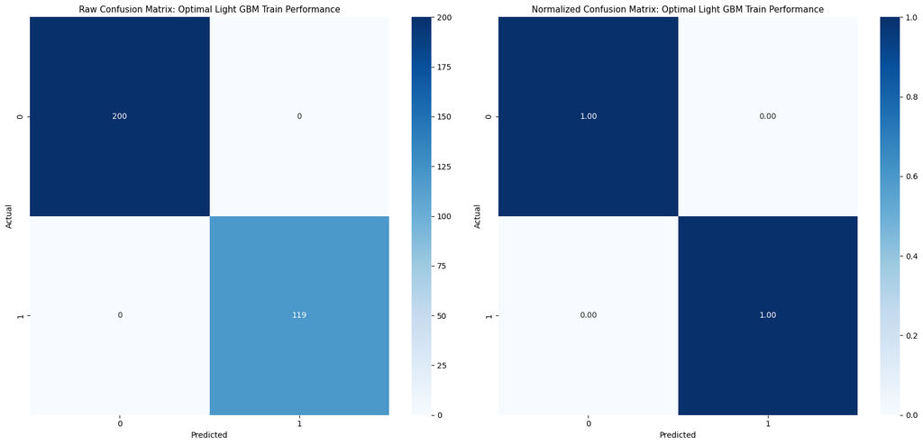

```python
##################################
# Formulating the raw and normalized
# confusion matrices
# from the train data
##################################
cm_raw = confusion_matrix(y_train_encoded, boosted_lgbm_optimal.predict(X_train))
cm_normalized = confusion_matrix(y_train_encoded, boosted_lgbm_optimal.predict(X_train), normalize='true')
fig, ax = plt.subplots(1, 2, figsize=(17, 8))
sns.heatmap(cm_raw, annot=True, fmt='d', cmap='Blues', ax=ax[0])
ax[0].set_title('Raw Confusion Matrix: Optimal Light GBM Train Performance', fontsize=11)
ax[0].set_xlabel('Predicted')
ax[0].set_ylabel('Actual')
sns.heatmap(cm_normalized, annot=True, fmt='.2f', cmap='Blues', ax=ax[1])
ax[1].set_title('Normalized Confusion Matrix: Optimal Light GBM Train Performance', fontsize=11)
ax[1].set_xlabel('Predicted')
ax[1].set_ylabel('Actual')
plt.tight_layout()
plt.show()
```

```python
##################################
# Summarizing the F1 score results
# and classification metrics
# on the validation data
# to assess overfitting optimism
##################################
print(f"F1 Score on Validation Data: {boosted_lgbm_optimal_f1_validation:.4f}")
print("\nClassification Report on Validation Data:\n", classification_report(y_validation_encoded, boosted_lgbm_optimal.predict(X_validation)))
```

```
F1 Score on Validation Data: 0.9351

Classification Report on Validation Data:
               precision    recall  f1-score   support

           0       0.94      0.99      0.96        67
           1       0.97      0.90      0.94        40

    accuracy                           0.95       107
   macro avg       0.96      0.94      0.95       107
weighted avg       0.95      0.95      0.95       107
```

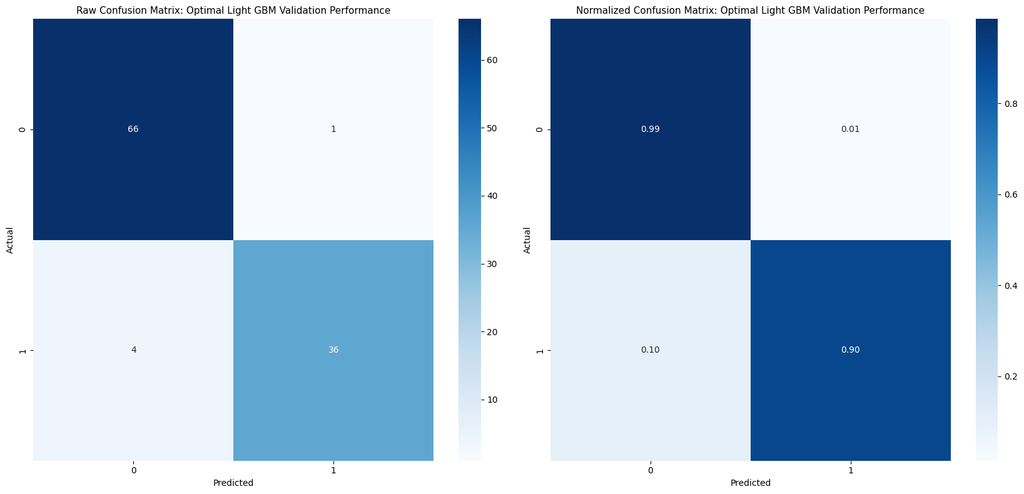

```python
##################################
# Formulating the raw and normalized
# confusion matrices
# from the validation data
##################################
cm_raw = confusion_matrix(y_validation_encoded, boosted_lgbm_optimal.predict(X_validation))
cm_normalized = confusion_matrix(y_validation_encoded, boosted_lgbm_optimal.predict(X_validation), normalize='true')
fig, ax = plt.subplots(1, 2, figsize=(17, 8))
sns.heatmap(cm_raw, annot=True, fmt='d', cmap='Blues', ax=ax[0])
ax[0].set_title('Raw Confusion Matrix: Optimal Light GBM Validation Performance', fontsize=11)
ax[0].set_xlabel('Predicted')
ax[0].set_ylabel('Actual')
sns.heatmap(cm_normalized, annot=True, fmt='.2f', cmap='Blues', ax=ax[1])
ax[1].set_title('Normalized Confusion Matrix: Optimal Light GBM Validation Performance', fontsize=11)
ax[1].set_xlabel('Predicted')
ax[1].set_ylabel('Actual')
plt.tight_layout()
plt.show()
```

```python
##################################
# Gathering the model evaluation metrics
# for the train data
##################################
boosted_lgbm_optimal_train = model_performance_evaluation(y_train_encoded, boosted_lgbm_optimal.predict(X_train))
boosted_lgbm_optimal_train['model'] = ['boosted_lgbm_optimal'] * 5
boosted_lgbm_optimal_train['set'] = ['train'] * 5
print('Optimal Light GBM Train Performance Metrics: ')
display(boosted_lgbm_optimal_train)
```

```
Optimal Light GBM Train Performance Metrics:
```

|  | metric_name | metric_value | model | set |
| --- | --- | --- | --- | --- |
| 0 | Accuracy | 1.0 | boosted_lgbm_optimal | train |
| 1 | Precision | 1.0 | boosted_lgbm_optimal | train |
| 2 | Recall | 1.0 | boosted_lgbm_optimal | train |
| 3 | F1 | 1.0 | boosted_lgbm_optimal | train |
| 4 | AUROC | 1.0 | boosted_lgbm_optimal | train |

```python
##################################
# Gathering the model evaluation metrics
# for the validation data
##################################
boosted_lgbm_optimal_validation = model_performance_evaluation(y_validation_encoded, boosted_lgbm_optimal.predict(X_validation))
boosted_lgbm_optimal_validation['model'] = ['boosted_lgbm_optimal'] * 5
boosted_lgbm_optimal_validation['set'] = ['validation'] * 5
print('Optimal Light GBM Validation Performance Metrics: ')
display(boosted_lgbm_optimal_validation)
```

```
Optimal Light GBM Validation Performance Metrics:
```

|  | metric_name | metric_value | model | set |
| --- | --- | --- | --- | --- |
| 0 | Accuracy | 0.953271 | boosted_lgbm_optimal | validation |
| 1 | Precision | 0.972973 | boosted_lgbm_optimal | validation |
| 2 | Recall | 0.900000 | boosted_lgbm_optimal | validation |
| 3 | F1 | 0.935065 | boosted_lgbm_optimal | validation |
| 4 | AUROC | 0.942537 | boosted_lgbm_optimal | validation |

```python
##################################
joblib.dump(boosted_lgbm_optimal,
            os.path.join("..", MODELS_PATH, "boosted_model_light_gbm_optimal.pkl"))
```

```
['..\\models\\boosted_model_light_gbm_optimal.pkl']
```

### 1.7.6 CatBoost

[CatBoost (Categorical Boosting)](https://catboost.ai/docs/en/concepts/python-reference_catboostclassifier) is a boosting algorithm optimized for categorical data. Unlike other gradient boosting methods that require categorical variables to be manually encoded, CatBoost handles them natively, reducing preprocessing effort and improving performance. It builds decision trees iteratively, like other boosting methods, but uses ordered boosting to prevent target leakage and enhance generalization. The main advantages of CatBoost are its ability to handle categorical data without extensive preprocessing, high accuracy with minimal tuning, and robustness against overfitting due to built-in regularization. Additionally, it is relatively fast and memory-efficient. However, CatBoost can still be slower than LightGBM on very large datasets, and while it requires less tuning, improper parameter selection can lead to suboptimal performance. Its internal mechanics, such as ordered boosting, make interpretation more complex compared to simpler models.

```python
##################################
# Defining the scaling and PCA preprocessing parameters
##################################
scaling_pca_preprocessor = Pipeline([
    ('scaler', StandardScaler()),
    ('pca', PCA(n_components=10, random_state=987654321))
])
```

```python
##################################
# Defining the preprocessing and modeling pipeline parameters
##################################
boosted_cb_pipeline = Pipeline([
    ('scaling_pca_preprocessor', scaling_pca_preprocessor),
    ('boosted_cb_model', CatBoostClassifier(scale_pos_weight=2.0,
                                            random_state=987654321,
                                            subsample =0.7,
                                            colsample_bylevel=0.7,
                                            grow_policy='Lossguide',
                                            verbose=0,
                                            allow_writing_files=False))
])
```

```python
##################################
# Defining hyperparameter grid
##################################
boosted_cb_hyperparameter_grid = {
    'boosted_cb_model__learning_rate': [0.01, 0.10],
    'boosted_cb_model__max_depth': [3, 6],
    'boosted_cb_model__num_leaves': [8, 16],
    'boosted_cb_model__iterations': [50, 100]
}
```

```python
##################################
# Defining the cross-validation strategy (5-cycle 5-fold CV)
##################################
cv_strategy = RepeatedStratifiedKFold(n_splits=5,
                                      n_repeats=5,
                                      random_state=987654321)
```

```python
##################################
# Performing Grid Search with cross-validation
##################################
boosted_cb_grid_search = GridSearchCV(
    estimator=boosted_cb_pipeline,
    param_grid=boosted_cb_hyperparameter_grid,
    scoring='f1',
    cv=cv_strategy,
    n_jobs=-1,
    verbose=1
)
```

```python
##################################
# Encoding the response variables
# for model training and validation
##################################
y_train_encoded = y_train.map({'B': 0, 'M': 1})
y_validation_encoded = y_validation.map({'B': 0, 'M': 1})
```

```python
##################################
# Fitting GridSearchCV
##################################
boosted_cb_grid_search.fit(X_train, y_train_encoded)
```

```
Fitting 25 folds for each of 16 candidates, totalling 400 fits
```

```
GridSearchCV(cv=RepeatedStratifiedKFold(n_repeats=5, n_splits=5, random_state=987654321),
             estimator=Pipeline(steps=[('scaling_pca_preprocessor',
                                        Pipeline(steps=[('scaler',
                                                         StandardScaler()),
                                                        ('pca',
                                                         PCA(n_components=10,
                                                             random_state=987654321))])),
                                       ('boosted_cb_model',
                                        <catboost.core.CatBoostClassifier object at 0x000001DE6F916180>)]),
             n_jobs=-1,
             param_grid={'boosted_cb_model__iterations': [50, 100],
                         'boosted_cb_model__learning_rate': [0.01, 0.1],
                         'boosted_cb_model__max_depth': [3, 6],
                         'boosted_cb_model__num_leaves': [8, 16]},
             scoring='f1', verbose=1)
```

```python
##################################
# Identifying the best model
##################################
boosted_cb_optimal = boosted_cb_grid_search.best_estimator_
```

```python
##################################
# Evaluating the F1 scores
# on the training, cross-validation, and validation data
##################################
boosted_cb_optimal_f1_cv = boosted_cb_grid_search.best_score_
boosted_cb_optimal_f1_train = f1_score(y_train_encoded, boosted_cb_optimal.predict(X_train))
boosted_cb_optimal_f1_validation = f1_score(y_validation_encoded, boosted_cb_optimal.predict(X_validation))
```

```python
##################################
# Identifying the optimal model
##################################
print('Best Boosted Model - CatBoost: ')
print(f"Best CatBoost Hyperparameters: {boosted_cb_grid_search.best_params_}")
```

```
Best Boosted Model - CatBoost:
Best CatBoost Hyperparameters: {'boosted_cb_model__iterations': 100, 'boosted_cb_model__learning_rate': 0.1, 'boosted_cb_model__max_depth': 6, 'boosted_cb_model__num_leaves': 8}
```

```python
##################################
# Summarizing the F1 score results
# and classification metrics
# on the training and cross-validated data
# to assess overfitting optimism
##################################
print(f"F1 Score on Cross-Validated Data: {boosted_cb_optimal_f1_cv:.4f}")
print(f"F1 Score on Training Data: {boosted_cb_optimal_f1_train:.4f}")
print("\nClassification Report on Train Data:\n", classification_report(y_train_encoded, boosted_cb_optimal.predict(X_train)))
```

```
F1 Score on Cross-Validated Data: 0.9295
F1 Score on Training Data: 0.9958

Classification Report on Train Data:
               precision    recall  f1-score   support

           0       1.00      0.99      1.00       200
           1       0.99      1.00      1.00       119

    accuracy                           1.00       319
   macro avg       1.00      1.00      1.00       319
weighted avg       1.00      1.00      1.00       319
```

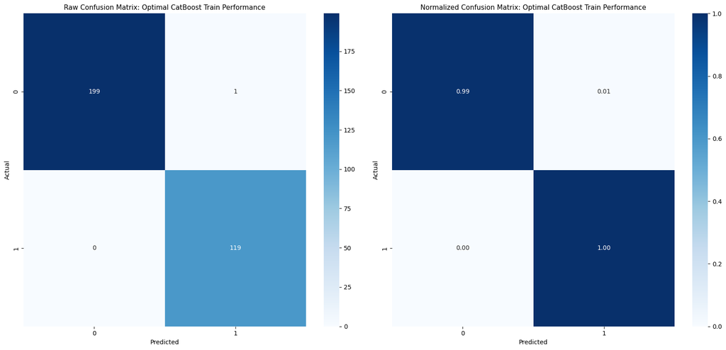

```python
##################################
# Formulating the raw and normalized
# confusion matrices
# from the train data
##################################
cm_raw = confusion_matrix(y_train_encoded, boosted_cb_optimal.predict(X_train))
cm_normalized = confusion_matrix(y_train_encoded, boosted_cb_optimal.predict(X_train), normalize='true')
fig, ax = plt.subplots(1, 2, figsize=(17, 8))
sns.heatmap(cm_raw, annot=True, fmt='d', cmap='Blues', ax=ax[0])
ax[0].set_title('Raw Confusion Matrix: Optimal CatBoost Train Performance', fontsize=11)
ax[0].set_xlabel('Predicted')
ax[0].set_ylabel('Actual')
sns.heatmap(cm_normalized, annot=True, fmt='.2f', cmap='Blues', ax=ax[1])
ax[1].set_title('Normalized Confusion Matrix: Optimal CatBoost Train Performance', fontsize=11)
ax[1].set_xlabel('Predicted')
ax[1].set_ylabel('Actual')
plt.tight_layout()
plt.show()
```

```python
##################################
# Summarizing the F1 score results
# and classification metrics
# on the validation data
# to assess overfitting optimism
##################################
print(f"F1 Score on Validation Data: {boosted_cb_optimal_f1_validation:.4f}")
print("\nClassification Report on Validation Data:\n", classification_report(y_validation_encoded, boosted_cb_optimal.predict(X_validation)))
```

```
F1 Score on Validation Data: 0.9487

Classification Report on Validation Data:
               precision    recall  f1-score   support

           0       0.96      0.99      0.97        67
           1       0.97      0.93      0.95        40

    accuracy                           0.96       107
   macro avg       0.97      0.96      0.96       107
weighted avg       0.96      0.96      0.96       107
```

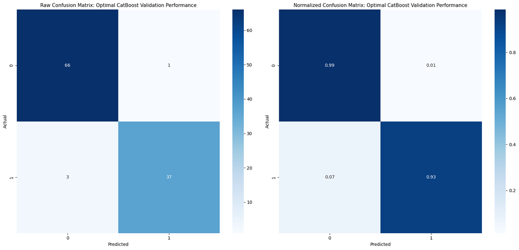

```python
##################################
# Formulating the raw and normalized
# confusion matrices
# from the validation data
##################################
cm_raw = confusion_matrix(y_validation_encoded, boosted_cb_optimal.predict(X_validation))
cm_normalized = confusion_matrix(y_validation_encoded, boosted_cb_optimal.predict(X_validation), normalize='true')
fig, ax = plt.subplots(1, 2, figsize=(17, 8))
sns.heatmap(cm_raw, annot=True, fmt='d', cmap='Blues', ax=ax[0])
ax[0].set_title('Raw Confusion Matrix: Optimal CatBoost Validation Performance', fontsize=11)
ax[0].set_xlabel('Predicted')
ax[0].set_ylabel('Actual')
sns.heatmap(cm_normalized, annot=True, fmt='.2f', cmap='Blues', ax=ax[1])
ax[1].set_title('Normalized Confusion Matrix: Optimal CatBoost Validation Performance', fontsize=11)
ax[1].set_xlabel('Predicted')
ax[1].set_ylabel('Actual')
plt.tight_layout()
plt.show()
```

```python
##################################
# Gathering the model evaluation metrics
# for the train data
##################################
boosted_cb_optimal_train = model_performance_evaluation(y_train_encoded, boosted_cb_optimal.predict(X_train))
boosted_cb_optimal_train['model'] = ['boosted_cb_optimal'] * 5
boosted_cb_optimal_train['set'] = ['train'] * 5
print('Optimal CatBoost Train Performance Metrics: ')
display(boosted_cb_optimal_train)
```

```
Optimal CatBoost Train Performance Metrics:
```

|  | metric_name | metric_value | model | set |
| --- | --- | --- | --- | --- |
| 0 | Accuracy | 0.996865 | boosted_cb_optimal | train |
| 1 | Precision | 0.991667 | boosted_cb_optimal | train |
| 2 | Recall | 1.000000 | boosted_cb_optimal | train |
| 3 | F1 | 0.995816 | boosted_cb_optimal | train |
| 4 | AUROC | 0.997500 | boosted_cb_optimal | train |

```python
##################################
# Gathering the model evaluation metrics
# for the validation data
##################################
boosted_cb_optimal_validation = model_performance_evaluation(y_validation_encoded, boosted_cb_optimal.predict(X_validation))
boosted_cb_optimal_validation['model'] = ['boosted_cb_optimal'] * 5
boosted_cb_optimal_validation['set'] = ['validation'] * 5
print('Optimal CatBoost Validation Performance Metrics: ')
display(boosted_cb_optimal_validation)
```

```
Optimal CatBoost Validation Performance Metrics:
```

|  | metric_name | metric_value | model | set |
| --- | --- | --- | --- | --- |
| 0 | Accuracy | 0.962617 | boosted_cb_optimal | validation |
| 1 | Precision | 0.973684 | boosted_cb_optimal | validation |
| 2 | Recall | 0.925000 | boosted_cb_optimal | validation |
| 3 | F1 | 0.948718 | boosted_cb_optimal | validation |
| 4 | AUROC | 0.955037 | boosted_cb_optimal | validation |

```python
##################################
# Saving the best individual model
# developed from the train data
##################################
joblib.dump(boosted_cb_optimal,
            os.path.join("..", MODELS_PATH, "boosted_model_catboost_optimal.pkl"))
```

```
['..\\models\\boosted_model_catboost_optimal.pkl']
```

## 1.8. Model Selection

```python
##################################
# Consolidating all the
# bagged, boosted, stacked and blended
# model performance measures
# for the train and validation data
##################################
ensemble_train_validation_all_performance = pd.concat([bagged_rf_optimal_train,
                                             bagged_rf_optimal_validation,
                                             boosted_ab_optimal_train,
                                             boosted_ab_optimal_validation,
                                             boosted_gb_optimal_train,
                                             boosted_gb_optimal_validation,
                                             boosted_xgb_optimal_train,
                                             boosted_xgb_optimal_validation,
                                             boosted_lgbm_optimal_train,
                                             boosted_lgbm_optimal_validation,
                                             boosted_cb_optimal_train,
                                             boosted_cb_optimal_validation],
                                            ignore_index=True)
print('Consolidated Ensemble Model Performance on Train and Validation Data: ')
display(ensemble_train_validation_all_performance)
```

```
Consolidated Ensemble Model Performance on Train and Validation Data:
```

|  | metric_name | metric_value | model | set |
| --- | --- | --- | --- | --- |
| 0 | Accuracy | 0.974922 | bagged_rf_optimal | train |
| 1 | Precision | 0.974359 | bagged_rf_optimal | train |
| 2 | Recall | 0.957983 | bagged_rf_optimal | train |
| 3 | F1 | 0.966102 | bagged_rf_optimal | train |
| 4 | AUROC | 0.971492 | bagged_rf_optimal | train |
| 5 | Accuracy | 0.934579 | bagged_rf_optimal | validation |
| 6 | Precision | 0.971429 | bagged_rf_optimal | validation |
| 7 | Recall | 0.850000 | bagged_rf_optimal | validation |
| 8 | F1 | 0.906667 | bagged_rf_optimal | validation |
| 9 | AUROC | 0.917537 | bagged_rf_optimal | validation |
| 10 | Accuracy | 0.993730 | boosted_ab_optimal | train |
| 11 | Precision | 1.000000 | boosted_ab_optimal | train |
| 12 | Recall | 0.983193 | boosted_ab_optimal | train |
| 13 | F1 | 0.991525 | boosted_ab_optimal | train |
| 14 | AUROC | 0.991597 | boosted_ab_optimal | train |
| 15 | Accuracy | 0.943925 | boosted_ab_optimal | validation |
| 16 | Precision | 0.972222 | boosted_ab_optimal | validation |
| 17 | Recall | 0.875000 | boosted_ab_optimal | validation |
| 18 | F1 | 0.921053 | boosted_ab_optimal | validation |
| 19 | AUROC | 0.930037 | boosted_ab_optimal | validation |
| 20 | Accuracy | 1.000000 | boosted_gb_optimal | train |
| 21 | Precision | 1.000000 | boosted_gb_optimal | train |
| 22 | Recall | 1.000000 | boosted_gb_optimal | train |
| 23 | F1 | 1.000000 | boosted_gb_optimal | train |
| 24 | AUROC | 1.000000 | boosted_gb_optimal | train |
| 25 | Accuracy | 0.934579 | boosted_gb_optimal | validation |
| 26 | Precision | 0.971429 | boosted_gb_optimal | validation |
| 27 | Recall | 0.850000 | boosted_gb_optimal | validation |
| 28 | F1 | 0.906667 | boosted_gb_optimal | validation |
| 29 | AUROC | 0.917537 | boosted_gb_optimal | validation |
| 30 | Accuracy | 1.000000 | boosted_xgb_optimal | train |
| 31 | Precision | 1.000000 | boosted_xgb_optimal | train |
| 32 | Recall | 1.000000 | boosted_xgb_optimal | train |
| 33 | F1 | 1.000000 | boosted_xgb_optimal | train |
| 34 | AUROC | 1.000000 | boosted_xgb_optimal | train |
| 35 | Accuracy | 0.943925 | boosted_xgb_optimal | validation |
| 36 | Precision | 0.972222 | boosted_xgb_optimal | validation |
| 37 | Recall | 0.875000 | boosted_xgb_optimal | validation |
| 38 | F1 | 0.921053 | boosted_xgb_optimal | validation |
| 39 | AUROC | 0.930037 | boosted_xgb_optimal | validation |
| 40 | Accuracy | 1.000000 | boosted_lgbm_optimal | train |
| 41 | Precision | 1.000000 | boosted_lgbm_optimal | train |
| 42 | Recall | 1.000000 | boosted_lgbm_optimal | train |
| 43 | F1 | 1.000000 | boosted_lgbm_optimal | train |
| 44 | AUROC | 1.000000 | boosted_lgbm_optimal | train |
| 45 | Accuracy | 0.953271 | boosted_lgbm_optimal | validation |
| 46 | Precision | 0.972973 | boosted_lgbm_optimal | validation |
| 47 | Recall | 0.900000 | boosted_lgbm_optimal | validation |
| 48 | F1 | 0.935065 | boosted_lgbm_optimal | validation |
| 49 | AUROC | 0.942537 | boosted_lgbm_optimal | validation |
| 50 | Accuracy | 0.996865 | boosted_cb_optimal | train |
| 51 | Precision | 0.991667 | boosted_cb_optimal | train |
| 52 | Recall | 1.000000 | boosted_cb_optimal | train |
| 53 | F1 | 0.995816 | boosted_cb_optimal | train |
| 54 | AUROC | 0.997500 | boosted_cb_optimal | train |
| 55 | Accuracy | 0.962617 | boosted_cb_optimal | validation |
| 56 | Precision | 0.973684 | boosted_cb_optimal | validation |
| 57 | Recall | 0.925000 | boosted_cb_optimal | validation |
| 58 | F1 | 0.948718 | boosted_cb_optimal | validation |
| 59 | AUROC | 0.955037 | boosted_cb_optimal | validation |

```python
##################################
# Consolidating all the F1 score
# model performance measures
# between the train and validation data
##################################
ensemble_train_validation_all_performance_F1 = ensemble_train_validation_all_performance[ensemble_train_validation_all_performance['metric_name']=='F1']
ensemble_train_validation_all_performance_F1_train = ensemble_train_validation_all_performance_F1[ensemble_train_validation_all_performance_F1['set']=='train'].loc[:,"metric_value"]
ensemble_train_validation_all_performance_F1_validation = ensemble_train_validation_all_performance_F1[ensemble_train_validation_all_performance_F1['set']=='validation'].loc[:,"metric_value"]
```

```python
##################################
# Combining all the F1 score
# model performance measures
# between the train and validation data
##################################
ensemble_train_validation_all_performance_F1_plot = pd.DataFrame({'train': ensemble_train_validation_all_performance_F1_train.values,
                                                              'validation': ensemble_train_validation_all_performance_F1_validation.values},
                                                             index=ensemble_train_validation_all_performance_F1['model'].unique())
ensemble_train_validation_all_performance_F1_plot
```

|  | train | validation |
| --- | --- | --- |
| bagged_rf_optimal | 0.966102 | 0.906667 |
| boosted_ab_optimal | 0.991525 | 0.921053 |
| boosted_gb_optimal | 1.000000 | 0.906667 |
| boosted_xgb_optimal | 1.000000 | 0.921053 |
| boosted_lgbm_optimal | 1.000000 | 0.935065 |
| boosted_cb_optimal | 0.995816 | 0.948718 |

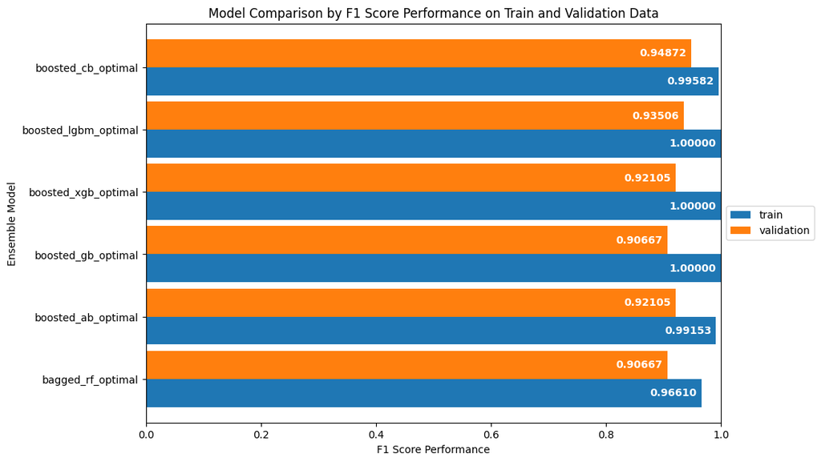

```python
##################################
# Plotting all the F1 score
# model performance measures
# between the train and validation sets
##################################
ensemble_train_validation_all_performance_F1_plot = ensemble_train_validation_all_performance_F1_plot.plot.barh(figsize=(10, 7), width=0.9)
ensemble_train_validation_all_performance_F1_plot.set_xlim(0.00,1.00)
ensemble_train_validation_all_performance_F1_plot.set_title("Model Comparison by F1 Score Performance on Train and Validation Data")
ensemble_train_validation_all_performance_F1_plot.set_xlabel("F1 Score Performance")
ensemble_train_validation_all_performance_F1_plot.set_ylabel("Ensemble Model")
ensemble_train_validation_all_performance_F1_plot.grid(False)
ensemble_train_validation_all_performance_F1_plot.legend(loc='center left', bbox_to_anchor=(1.0, 0.5))
for container in ensemble_train_validation_all_performance_F1_plot.containers:
    ensemble_train_validation_all_performance_F1_plot.bar_label(container, fmt='%.5f', padding=-50, color='white', fontweight='bold')
```

```python
##################################
# Gathering all model performance measures
# for the validation data
##################################
ensemble_train_validation_all_performance_Accuracy_validation = ensemble_train_validation_all_performance[(ensemble_train_validation_all_performance['set']=='validation') & (ensemble_train_validation_all_performance['metric_name']=='Accuracy')].loc[:,"metric_value"]
ensemble_train_validation_all_performance_Precision_validation = ensemble_train_validation_all_performance[(ensemble_train_validation_all_performance['set']=='validation') & (ensemble_train_validation_all_performance['metric_name']=='Precision')].loc[:,"metric_value"]
ensemble_train_validation_all_performance_Recall_validation = ensemble_train_validation_all_performance[(ensemble_train_validation_all_performance['set']=='validation') & (ensemble_train_validation_all_performance['metric_name']=='Recall')].loc[:,"metric_value"]
ensemble_train_validation_all_performance_F1_validation = ensemble_train_validation_all_performance[(ensemble_train_validation_all_performance['set']=='validation') & (ensemble_train_validation_all_performance['metric_name']=='F1')].loc[:,"metric_value"]
ensemble_train_validation_all_performance_AUROC_validation = ensemble_train_validation_all_performance[(ensemble_train_validation_all_performance['set']=='validation') & (ensemble_train_validation_all_performance['metric_name']=='AUROC')].loc[:,"metric_value"]
```

```python
##################################
# Combining all the model performance measures
# for the validation data
##################################
ensemble_train_validation_all_performance_all_plot_validation = pd.DataFrame({'accuracy': ensemble_train_validation_all_performance_Accuracy_validation.values,
                                                                    'precision': ensemble_train_validation_all_performance_Precision_validation.values,
                                                                    'recall': ensemble_train_validation_all_performance_Recall_validation.values,
                                                                    'f1': ensemble_train_validation_all_performance_F1_validation.values,
                                                                    'auroc': ensemble_train_validation_all_performance_AUROC_validation.values},
                                                                   index=ensemble_train_validation_all_performance['model'].unique())
ensemble_train_validation_all_performance_all_plot_validation
```

|  | accuracy | precision | recall | f1 | auroc |
| --- | --- | --- | --- | --- | --- |
| bagged_rf_optimal | 0.934579 | 0.971429 | 0.850 | 0.906667 | 0.917537 |
| boosted_ab_optimal | 0.943925 | 0.972222 | 0.875 | 0.921053 | 0.930037 |
| boosted_gb_optimal | 0.934579 | 0.971429 | 0.850 | 0.906667 | 0.917537 |
| boosted_xgb_optimal | 0.943925 | 0.972222 | 0.875 | 0.921053 | 0.930037 |
| boosted_lgbm_optimal | 0.953271 | 0.972973 | 0.900 | 0.935065 | 0.942537 |
| boosted_cb_optimal | 0.962617 | 0.973684 | 0.925 | 0.948718 | 0.955037 |

```python
##################################
# Gathering the model evaluation metrics
# for the test data
##################################
##################################
# Defining a dictionary of models and
# their corresponding optimal model functions
##################################
models = {
    'bagged_rf_optimal': bagged_rf_optimal,
    'boosted_ab_optimal': boosted_ab_optimal,
    'boosted_gb_optimal': boosted_gb_optimal,
    'boosted_xgb_optimal': boosted_xgb_optimal,
    'boosted_lgbm_optimal': boosted_lgbm_optimal,
    'boosted_cb_optimal': boosted_cb_optimal
}
```

```python
##################################
# Encoding the response variables
# for model testing
##################################
y_test_encoded = y_test.map({'B': 0, 'M': 1})
```

```python
##################################
# Storing the model evaluation metrics
# for the test data
##################################
ensemble_test_all_performance = []

##################################
# Looping through each model
# and evaluate performance on test data
##################################
for model_name, model in models.items():

    # Evaluating performance
    ensemble_test_all_performance_results = model_performance_evaluation(y_test_encoded, model.predict(X_test))

    # Adding metadata columns
    ensemble_test_all_performance_results['model'] = model_name
    ensemble_test_all_performance_results['set'] = 'test'

    # Storing result
    ensemble_test_all_performance.append(ensemble_test_all_performance_results)
```

```python
##################################
# Consolidating all model performance measures
# for the test data
##################################
ensemble_test_all_performance = pd.concat(ensemble_test_all_performance, ignore_index=True)
print('Consolidated Ensemble Model Performance on Test Data: ')
display(ensemble_test_all_performance)
```

```
Consolidated Ensemble Model Performance on Test Data:
```

|  | metric_name | metric_value | model | set |
| --- | --- | --- | --- | --- |
| 0 | Accuracy | 0.944056 | bagged_rf_optimal | test |
| 1 | Precision | 0.941176 | bagged_rf_optimal | test |
| 2 | Recall | 0.905660 | bagged_rf_optimal | test |
| 3 | F1 | 0.923077 | bagged_rf_optimal | test |
| 4 | AUROC | 0.936164 | bagged_rf_optimal | test |
| 5 | Accuracy | 0.979021 | boosted_ab_optimal | test |
| 6 | Precision | 0.980769 | boosted_ab_optimal | test |
| 7 | Recall | 0.962264 | boosted_ab_optimal | test |
| 8 | F1 | 0.971429 | boosted_ab_optimal | test |
| 9 | AUROC | 0.975577 | boosted_ab_optimal | test |
| 10 | Accuracy | 0.965035 | boosted_gb_optimal | test |
| 11 | Precision | 0.944444 | boosted_gb_optimal | test |
| 12 | Recall | 0.962264 | boosted_gb_optimal | test |
| 13 | F1 | 0.953271 | boosted_gb_optimal | test |
| 14 | AUROC | 0.964465 | boosted_gb_optimal | test |
| 15 | Accuracy | 0.965035 | boosted_xgb_optimal | test |
| 16 | Precision | 0.944444 | boosted_xgb_optimal | test |
| 17 | Recall | 0.962264 | boosted_xgb_optimal | test |
| 18 | F1 | 0.953271 | boosted_xgb_optimal | test |
| 19 | AUROC | 0.964465 | boosted_xgb_optimal | test |
| 20 | Accuracy | 0.979021 | boosted_lgbm_optimal | test |
| 21 | Precision | 0.962963 | boosted_lgbm_optimal | test |
| 22 | Recall | 0.981132 | boosted_lgbm_optimal | test |
| 23 | F1 | 0.971963 | boosted_lgbm_optimal | test |
| 24 | AUROC | 0.979455 | boosted_lgbm_optimal | test |
| 25 | Accuracy | 0.965035 | boosted_cb_optimal | test |
| 26 | Precision | 0.913793 | boosted_cb_optimal | test |
| 27 | Recall | 1.000000 | boosted_cb_optimal | test |
| 28 | F1 | 0.954955 | boosted_cb_optimal | test |
| 29 | AUROC | 0.972222 | boosted_cb_optimal | test |

```python
##################################
# Gathering all model performance measures
# for the test data
##################################
ensemble_test_all_performance_Accuracy_test = ensemble_test_all_performance[(ensemble_test_all_performance['set']=='test') & (ensemble_test_all_performance['metric_name']=='Accuracy')].loc[:,"metric_value"]
ensemble_test_all_performance_Precision_test = ensemble_test_all_performance[(ensemble_test_all_performance['set']=='test') & (ensemble_test_all_performance['metric_name']=='Precision')].loc[:,"metric_value"]
ensemble_test_all_performance_Recall_test = ensemble_test_all_performance[(ensemble_test_all_performance['set']=='test') & (ensemble_test_all_performance['metric_name']=='Recall')].loc[:,"metric_value"]
ensemble_test_all_performance_F1_test = ensemble_test_all_performance[(ensemble_test_all_performance['set']=='test') & (ensemble_test_all_performance['metric_name']=='F1')].loc[:,"metric_value"]
ensemble_test_all_performance_AUROC_test = ensemble_test_all_performance[(ensemble_test_all_performance['set']=='test') & (ensemble_test_all_performance['metric_name']=='AUROC')].loc[:,"metric_value"]
```

```python
##################################
# Combining all the model performance measures
# for the test data
##################################
ensemble_test_all_performance_all_plot_test = pd.DataFrame({'accuracy': ensemble_test_all_performance_Accuracy_test.values,
                                                            'precision': ensemble_test_all_performance_Precision_test.values,
                                                            'recall': ensemble_test_all_performance_Recall_test.values,
                                                            'f1': ensemble_test_all_performance_F1_test.values,
                                                            'auroc': ensemble_test_all_performance_AUROC_test.values},
                                                           index=ensemble_test_all_performance['model'].unique())
ensemble_test_all_performance_all_plot_test
```

|  | accuracy | precision | recall | f1 | auroc |
| --- | --- | --- | --- | --- | --- |
| bagged_rf_optimal | 0.944056 | 0.941176 | 0.905660 | 0.923077 | 0.936164 |
| boosted_ab_optimal | 0.979021 | 0.980769 | 0.962264 | 0.971429 | 0.975577 |
| boosted_gb_optimal | 0.965035 | 0.944444 | 0.962264 | 0.953271 | 0.964465 |
| boosted_xgb_optimal | 0.965035 | 0.944444 | 0.962264 | 0.953271 | 0.964465 |
| boosted_lgbm_optimal | 0.979021 | 0.962963 | 0.981132 | 0.971963 | 0.979455 |
| boosted_cb_optimal | 0.965035 | 0.913793 | 1.000000 | 0.954955 | 0.972222 |

```python
##################################
# Consolidating all the final
# bagged, boosted, stacked and blended
# model performance measures
# for the train, validation and test data
##################################
ensemble_overall_performance = pd.concat([ensemble_train_validation_all_performance, ensemble_test_all_performance], axis=0)
```

```python
##################################
# Consolidating all the F1 score
# model performance measures
# between the train, validation and test data
##################################
ensemble_overall_performance_F1 = ensemble_overall_performance[ensemble_overall_performance['metric_name']=='F1']
ensemble_overall_performance_F1_train = ensemble_overall_performance_F1[ensemble_overall_performance_F1['set']=='train'].loc[:,"metric_value"]
ensemble_overall_performance_F1_validation = ensemble_overall_performance_F1[ensemble_overall_performance_F1['set']=='validation'].loc[:,"metric_value"]
ensemble_overall_performance_F1_test = ensemble_overall_performance_F1[ensemble_overall_performance_F1['set']=='test'].loc[:,"metric_value"]
```

```python
##################################
# Combining all the F1 score
# model performance measures
# between the train and validation data
##################################
ensemble_overall_performance_F1_plot = pd.DataFrame({'train': ensemble_overall_performance_F1_train.values,
                                                     'validation': ensemble_overall_performance_F1_validation.values,
                                                     'test': ensemble_overall_performance_F1_test.values},
                                                    index=ensemble_overall_performance_F1['model'].unique())
ensemble_overall_performance_F1_plot
```

|  | train | validation | test |
| --- | --- | --- | --- |
| bagged_rf_optimal | 0.966102 | 0.906667 | 0.923077 |
| boosted_ab_optimal | 0.991525 | 0.921053 | 0.971429 |
| boosted_gb_optimal | 1.000000 | 0.906667 | 0.953271 |
| boosted_xgb_optimal | 1.000000 | 0.921053 | 0.953271 |
| boosted_lgbm_optimal | 1.000000 | 0.935065 | 0.971963 |
| boosted_cb_optimal | 0.995816 | 0.948718 | 0.954955 |

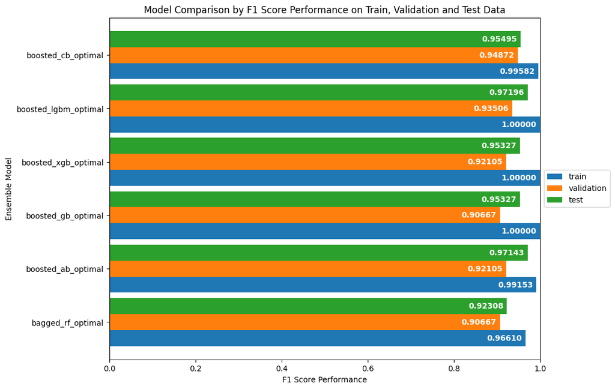

```python
##################################
# Plotting all the F1 score
# model performance measures
# between train, validation and test sets
##################################
ensemble_overall_performance_F1_plot = ensemble_overall_performance_F1_plot.plot.barh(figsize=(10, 8), width=0.9)
ensemble_overall_performance_F1_plot.set_xlim(0.00,1.00)
ensemble_overall_performance_F1_plot.set_title("Model Comparison by F1 Score Performance on Train, Validation and Test Data")
ensemble_overall_performance_F1_plot.set_xlabel("F1 Score Performance")
ensemble_overall_performance_F1_plot.set_ylabel("Ensemble Model")
ensemble_overall_performance_F1_plot.grid(False)
ensemble_overall_performance_F1_plot.legend(loc='center left', bbox_to_anchor=(1.0, 0.5))
for container in ensemble_overall_performance_F1_plot.containers:
    ensemble_overall_performance_F1_plot.bar_label(container, fmt='%.5f', padding=-50, color='white', fontweight='bold')
```

## 1.9. Model Monitoring using the NannyML Framework

### 1.9.1 Baseline Control

```python
##################################
# Defining the global parameters
# for the post-model deployment scenario simulation
##################################
N_CHUNKS = 21
CHUNK_SIZE = 75
RANDOM_STATE = 987654321
TARGET_COL = 'diagnosis'
LABEL_MAP = {'B': 0, 'M': 1}
FEATURE_COLUMNS = [
'radius_mean','texture_mean','perimeter_mean','area_mean','smoothness_mean',
'compactness_mean','concavity_mean','concave points_mean','symmetry_mean','fractal_dimension_mean',
'radius_se','texture_se','perimeter_se','area_se','smoothness_se',
'compactness_se','concavity_se','concave points_se','symmetry_se','fractal_dimension_se',
'radius_worst','texture_worst','perimeter_worst','area_worst','smoothness_worst',
'compactness_worst','concavity_worst','concave points_worst','symmetry_worst','fractal_dimension_worst'
]
```

```python
##################################
# Defining a function for generating
# a post-model data stream simulation
##################################
def make_stream_from_dataframe(df, n_chunks=N_CHUNKS, chunk_size=CHUNK_SIZE, random_state=RANDOM_STATE):
    """Creates a synthetic ordered stream (chunks) including at least one instance of both 'M' and 'B' classes."""
    # Initialiing a random number generator for reproducibility
    rng = np.random.RandomState(random_state)
    # Initializing an empty list to store each generated chunk
    rows = []

    # Splitting the dataframe into the two classes
    df_M = df[df[TARGET_COL] == "M"]
    df_B = df[df[TARGET_COL] == "B"]

    # Determining roughly balanced counts per chunk
    half_size = chunk_size // 2

    # Iterating through the desired number of chunks (simulated time intervals)
    for chunk_idx in range(n_chunks):
        # Sampling half of the chunk from each class (with replacement)
        sample_M = df_M.sample(
            n=half_size, replace=True, random_state=rng.randint(0, 2**31 - 1)
        )
        sample_B = df_B.sample(
            n=chunk_size - half_size, replace=True, random_state=rng.randint(0, 2**31 - 1)
        )

        # Combining, shuffling, and labeling with chunk/time index
        chunk = pd.concat([sample_M, sample_B], ignore_index=True).sample(
            frac=1, random_state=rng.randint(0, 2**31 - 1)
        )
        chunk["__chunk"] = chunk_idx
        chunk["__timestamp"] = chunk_idx

        rows.append(chunk)
    # Combining all chunks into a single DataFrame that represents a continuous data stream
    return pd.concat(rows, ignore_index=True)
```

```python
##################################
# Defining a function for
# computing model predictions and probabilities
# using the final selected model - categorical boosting model
##################################
def compute_preds_and_proba(pipeline, X):
    """Returns predicted labels and class 1 probabilities"""
    # Generating predicted class labels (0 or 1) using the trained model pipeline
    y_pred = pipeline.predict(X)
    try:
        # Obtaining the probability of the positive class (class 1)
        y_proba = pipeline.predict_proba(X)[:, 1]
    except Exception:
        # Computing the probability approximation if predict_proba is unavailable
        y_proba = 1 / (1 + np.exp(-pipeline.decision_function(X)))
    # Returning both predicted labels and corresponding class-1 probabilities
    return y_pred, y_proba
```

```python
##################################
# Defining a function for fitting
# NannyML reference calculators
# on the baseline reference dataset
##################################
def fit_nannyml_reference(reference_df, boosted_cb_optimal):
    """
    Fit NannyML reference calculators (univariate drift + CBPE) on the baseline reference dataset.
    Returns a dictionary containing fitted NannyML objects.
    """
    # Extracting the feature matrix (X) and map target labels to numeric values
    X = reference_df[FEATURE_COLUMNS]
    y_true = reference_df[TARGET_COL].map(LABEL_MAP)

    # Computing model predictions and predicted probabilities for the reference data
    y_pred, y_proba = compute_preds_and_proba(boosted_cb_optimal, X)

    # Creating a working copy of the reference DataFrame with prediction columns added
    ref = reference_df.copy()
    ref['y_true'] = y_true
    ref['y_pred'] = y_pred
    ref['y_pred_proba'] = y_proba

    # Initializing and fitting a univariate drift calculator (e.g., KS-test, AD-test)
    uni = nml.UnivariateDriftCalculator(
        column_names=FEATURE_COLUMNS,
        chunk_size=CHUNK_SIZE
    ).fit(ref)

    # Initializing and fitting a CBPE (Confidence-Based Performance Estimation) object
    cbpe = nml.CBPE(
        y_true='y_true',
        y_pred='y_pred',
        y_pred_proba='y_pred_proba',
        problem_type='classification_binary',
        metrics=['roc_auc']
    ).fit(ref)

    # Returning both fitted objects inside a dictionary
    return {'ref': ref, 'uni': uni, 'cbpe': cbpe}
```

```python
##################################
# Defining a function for assessing
# a simulated monitoring scenario
# using fitted NannyML reference models
##################################
def assess_scenario(name, reference_fit, scenario_df, boosted_cb_optimal):
    """
    Assess a simulated monitoring scenario using fitted NannyML reference models.
    Computes drift and performance estimates, and compares with true AUC per chunk.
    """
    # Creating a copy of the scenario data to avoid mutating the original
    df = scenario_df.copy()

    # Mapping the categorical target labels ('B', 'M') to numeric form (0, 1)
    df['y_true'] = df[TARGET_COL].map(LABEL_MAP)

    # Extracting feature columns for prediction
    X = df[FEATURE_COLUMNS]

    # Computing model predictions and predicted probabilities for this scenario
    y_pred, y_proba = compute_preds_and_proba(boosted_cb_optimal, X)

    # Storing predictions in the dataframe
    df['y_pred'] = y_pred
    df['y_pred_proba'] = y_proba

    # Using the fitted reference univariate drift calculator on this monitoring data
    uni_res = reference_fit['uni'].calculate(df)

    # Using the fitted reference CBPE performance estimator to estimate metrics without labels
    cbpe_res = reference_fit['cbpe'].estimate(df)

    # Computing the true AUC per chunk (only when labels are available)
    aucs = df.groupby('__chunk').apply(
        lambda g: roc_auc_score(g['y_true'], g['y_pred_proba'])
        if len(np.unique(g['y_true'])) > 1 else np.nan
    )

    # Printing the mean true AUC across all chunks for quick diagnostic comparison
    print(f"\nScenario {name}: Mean true AUC = {aucs.mean():.3f}")

    # Returning results in a dictionary for structured access
    return {
        'data': df,       # full scenario dataframe with predictions
        'uni': uni_res,   # univariate drift results
        'cbpe': cbpe_res, # CBPE performance estimates
        'true_auc': aucs  # actual AUC per chunk
    }
```

```python
##################################
# Defining a function for visualizing
# the distribution drift of an identified feature
##################################
def plot_feature_drift(df_ref, df_scenario, feature):
    """
    Visualize the distribution drift of a specific feature
    between reference and scenario datasets.
    """
    # Creating a figure with a defined size
    plt.figure(figsize=(8, 4))

    # Plotting the histogram of the reference feature distribution
    plt.hist(df_ref[feature], bins=30, alpha=0.5, label='Reference')

    # Plot the histogram of the scenario (drifted) feature distribution
    plt.hist(df_scenario[feature], bins=30, alpha=0.5, label='Scenario')

    # Adding a title indicating which feature is being visualized
    plt.title(f"Feature Distribution Drift: {feature}")

    # Adding a legend to distinguish the reference and scenario plots
    plt.legend()

    # Displaying the resulting histogram comparison
    plt.show()
```

```python
##################################
# Defining a function for comparing
# the true model performance
# and NannyML’s estimated performance (CBPE)
##################################
def plot_true_vs_estimated_performance(true_auc_series, cbpe_results):
    """
    Compare true model performance (AUC) vs. NannyML’s estimated performance (CBPE).
    """
    # Extracting the CBPE-estimated AUC values
    if hasattr(cbpe_results, "to_df"):
        cbpe_df = cbpe_results.to_df()
    else:
        cbpe_df = cbpe_results

    # Flattening MultiIndex columns if present
    if isinstance(cbpe_df.columns, pd.MultiIndex):
        cbpe_df.columns = ['_'.join(col).strip() for col in cbpe_df.columns.values]

    # Inspecting possible column names for chunk info
    possible_chunk_cols = [c for c in cbpe_df.columns if 'chunk' in c.lower() or 'key' in c.lower()]
    if not possible_chunk_cols:
        print("\nAvailable columns in cbpe_df:\n", cbpe_df.columns)
        raise KeyError("No column containing 'chunk' or 'key' found in CBPE results. Inspect cbpe_df.columns.")
    chunk_col = possible_chunk_cols[0]

    # Choosing the first matching column
    chunk_col = possible_chunk_cols[0]

    # Detecting metric-value columns
    possible_value_cols = [c for c in cbpe_df.columns if 'value' in c.lower()]
    value_col = possible_value_cols[0] if possible_value_cols else cbpe_df.columns[-1]

    # Filtering for the ROC AUC metric
    if 'metric' in cbpe_df.columns:
        cbpe_df = cbpe_df[cbpe_df['metric'] == 'roc_auc']
    else:
        metric_like_cols = [col for col in cbpe_df.columns if 'roc_auc' in col.lower()]
        keep_cols = list({chunk_col, *metric_like_cols, value_col})
        cbpe_df = cbpe_df.loc[:, [c for c in keep_cols if c in cbpe_df.columns]]

    # Handling the renamed columns
    if chunk_col not in cbpe_df.columns:
        alt_chunk_cols = [c for c in cbpe_df.columns if 'chunk' in c.lower() or 'key' in c.lower()]
        if alt_chunk_cols:
            chunk_col = alt_chunk_cols[0]
        else:
            print("\nColumns available after filtering:\n", cbpe_df.columns)
            raise KeyError("Chunk column missing after filtering. Inspect cbpe_df.columns.")

    # Creating a new figure for visualization
    plt.figure(figsize=(20, 5))

    # Plotting the true AUC values per chunk (ground truth)
    plt.plot(true_auc_series.index, true_auc_series.values, '-o', label='True AUC')

    # Plotting the CBPE-estimated AUC values per chunk
    plt.plot(cbpe_df[chunk_col].values, cbpe_df[value_col].values, '-x', label='CBPE-Estimated AUC')

    # Labeling the x-axis as 'Chunk' (representing time or batch index)
    plt.xlabel('Chunk')

    # Labeling the y-axis as'AUC' (performance metric)
    plt.ylabel('AUC')

    # Adding an informative title
    plt.title('True vs Estimated AUC per Chunk')

    # Displaying the legend to distinguish between true and estimated values
    plt.legend()

    # Rendering the line plot
    plt.show()
```

```python
##################################
# Defining a function for visualizing
# the number of drift alerts triggered per feature
##################################
def plot_alert_counts(uni_results):
    """
    Visualize the number of drift alerts triggered per feature
    using NannyML's Univariate Drift Calculator results.
    """
    # Ranking features by the number of alerts detected
    ranked = nml.AlertCountRanker().rank(uni_results)

    # Creating a figure for bar chart visualization
    plt.figure(figsize=(15, 5))

    # Plotting a bar chart of features vs. number of drift alerts
    plt.bar(ranked['column_name'], ranked['number_of_alerts'])

    # Rotating the x-axis labels for better readability
    plt.xticks(rotation=90)

    # Adding a descriptive title to the chart
    plt.title('Feature Alert Count Ranking')

    # Adjusting layout to prevent label overlap
    plt.tight_layout()

    # Showing the resulting bar chart
    plt.show()
```

```python
##################################
# Defining a function for
# simulating the baseline control
##################################
def simulate_P1_baseline(df):
    # Creating a time-ordered synthetic stream of data chunks
    return make_stream_from_dataframe(df)
```

```python
##################################
# Defining a function for
# executing the NannyML monitoring
# for Scenario 1: Baseline Control
##################################
def run_nannyml_baseline_control(reference_df, boosted_cb_optimal):
    """
    Run the complete NannyML monitoring workflow for the baseline scenario (P1).
    """

    # Fitting the NannyML reference models (baseline reference period)
    ref_fit = fit_nannyml_reference(reference_df, boosted_cb_optimal)

    # Simulating baseline (no drift) scenario
    p1 = simulate_P1_baseline(reference_df)

    # Assessing scenario 1 using fitted reference and trained model
    r1 = assess_scenario('P1_baseline', ref_fit, p1, boosted_cb_optimal)

    # Plotting the comparison between true and estimated AUC per chunk
    plot_true_vs_estimated_performance(r1['true_auc'], r1['cbpe'])

    # Visualizing drift alert counts per feature
    plot_alert_counts(r1['uni'])
```